# Business Statistics End of Term Assessment IB94X0 2023-2024 #1

2053845

# Statement of Academic Integrity

This is to certify that the work I am submitting is my own. All external references and sources are clearly acknowledged and identified within the contents. I am aware of the University of Warwick regulation concerning plagiarism and collusion.

No substantial part(s) of the work submitted here has also been submitted by me in other assessments for accredited courses of study, and I acknowledge that if this has been done an appropriate reduction in the mark I might otherwise have received will be made.

# Packages required

```r
library(dplyr)
library(tidyverse)
library(car)
library(ggplot2)
library(emmeans)
library(corrplot)
library(Rmisc)
library(Hmisc)
library(gridExtra)
```

# Question 1

## Brief

We are interested in the effect upon bike hire usage as a result of three elements of the COVID response: Work From Home, Rule of 6 Indoors, and the Eat Out to Help Out scheme. Use the data provided to perform regression analyses that examine the effect of these elements upon the number of bike rentals. You should also explore whether it is appropriate to control for the effect of potential differences between different years, months, and days of the week.

## Data Dictionary

| Variable | Description |
| --- | --- |
| data | The specific dates when a certain number of bicycles were rented. |
| Hires | The total quantity of bicycles rented on a specified date. |
| schools_closed | Represents if a “schools closed” regulation was implemented; (1 means active, 0 means inactive) |
| pubs_closed | Represents if a ‘pubs_closed’ regulatio was implemented; (1 means active, 0 means inactive) |
| shops_closed | Represents if a ‘shops_closed’ regulatio was implemented (1 means active, 0 means inactive) |
| eating_places_closed | Represents if a ‘eating_places_closed’ policy was implemented (1 means active, 0 means inactive) |
| stay_at_home | Represents if a ‘stay_at_home’ policy was implemted (1 means active, 0 means inactive) |
| household_mixing_indoors_banned | Represents if a ‘household_mixing_indoors_banned’ policy was implemted (1 means active, 0 means inactive) |
| wfh | Represents if a ‘wfh’ policy was implemted (1 means active, 0 means inactive) |
| curfew | Represents if a ‘curfew’ policy was implemted (1 means active, 0 means inactive) |
| eat_out_to_help_out | Represents if a ‘eat_out_to_help_out’ policy was implemted (1 means active, 0 means inactive) |
| day | day of the week on the given date |
| month | Month on the given date |
| year | Year on the given date |

## Data Preparation

First, we will read and import the.csv data file, and generate a summary.

```r
# Reading the .csv datafile and importing it as 'datasetBikeHires'
datasetBikeHires <- read.csv("London_COVID_bikes.csv", stringsAsFactors = TRUE)

# Summary of the dataset
summary(datasetBikeHires)
```

```
##          date          Hires       schools_closed     pubs_closed
##  2021-12-13:   2   Min.   :    0   Min.   :0.00000   Min.   :0.00000
##  2010-07-30:   1   1st Qu.:19776   1st Qu.:0.00000   1st Qu.:0.00000
##  2010-07-31:   1   Median :26356   Median :0.00000   Median :0.00000
##  2010-08-01:   1   Mean   :26607   Mean   :0.02743   Mean   :0.05175
##  2010-08-02:   1   3rd Qu.:33481   3rd Qu.:0.00000   3rd Qu.:0.00000
##  2010-08-03:   1   Max.   :73094   Max.   :1.00000   Max.   :1.00000
##  (Other)   :4805
##   shops_closed     eating_places_closed  stay_at_home
##  Min.   :0.00000   Min.   :0.00000      Min.   :0.00000
##  1st Qu.:0.00000   1st Qu.:0.00000      1st Qu.:0.00000
##  Median :0.00000   Median :0.00000      Median :0.00000
##  Mean   :0.04634   Mean   :0.05175      Mean   :0.03616
##  3rd Qu.:0.00000   3rd Qu.:0.00000      3rd Qu.:0.00000
##  Max.   :1.00000   Max.   :1.00000      Max.   :1.00000
##
##  household_mixing_indoors_banned      wfh         rule_of_6_indoors
##  Min.   :0.00000                 Min.   :0.0000   Min.   :0.00000
##  1st Qu.:0.00000                 1st Qu.:0.0000   1st Qu.:0.00000
##  Median :0.00000                 Median :0.0000   Median :0.00000
##  Mean   :0.06525                 Mean   :0.2273   Mean   :0.01995
##  3rd Qu.:0.00000                 3rd Qu.:0.0000   3rd Qu.:0.00000
##  Max.   :1.00000                 Max.   :1.0000   Max.   :1.00000
##
##      curfew        eat_out_to_help_out  day          month           year
##  Min.   :0.00000   Min.   :0.000000    Fri:688   Aug    : 434   Min.   :2010
##  1st Qu.:0.00000   1st Qu.:0.000000    Mon:688   Sep    : 420   1st Qu.:2013
##  Median :0.00000   Median :0.000000    Sat:688   Jul    : 405   Median :2017
##  Mean   :0.01164   Mean   :0.005819    Sun:687   Dec    : 404   Mean   :2017
##  3rd Qu.:0.00000   3rd Qu.:0.000000    Thu:687   Jan    : 403   3rd Qu.:2020
##  Max.   :1.00000   Max.   :1.000000    Tue:687   Mar    : 403   Max.   :2023
##                                        Wed:687   (Other):2343
```

```r
str(datasetBikeHires)
```

```
## 'data.frame':    4812 obs. of  15 variables:
##  $ date                           : Factor w/ 4811 levels "2010-07-30","2010-07-31",..: 1 2 3 4 5 6 7 8 9 10 ...
##  $ Hires                          : int  6897 5564 4303 6642 7966 7893 8724 9797 6631 7864 ...
##  $ schools_closed                 : int  0 0 0 0 0 0 0 0 0 0 ...
##  $ pubs_closed                    : int  0 0 0 0 0 0 0 0 0 0 ...
##  $ shops_closed                   : int  0 0 0 0 0 0 0 0 0 0 ...
##  $ eating_places_closed           : int  0 0 0 0 0 0 0 0 0 0 ...
##  $ stay_at_home                   : int  0 0 0 0 0 0 0 0 0 0 ...
##  $ household_mixing_indoors_banned: int  0 0 0 0 0 0 0 0 0 0 ...
##  $ wfh                            : int  0 0 0 0 0 0 0 0 0 0 ...
##  $ rule_of_6_indoors              : int  0 0 0 0 0 0 0 0 0 0 ...
##  $ curfew                         : int  0 0 0 0 0 0 0 0 0 0 ...
##  $ eat_out_to_help_out            : int  0 0 0 0 0 0 0 0 0 0 ...
##  $ day                            : Factor w/ 7 levels "Fri","Mon","Sat",..: 1 3 4 2 6 7 5 1 3 4 ...
##  $ month                          : Factor w/ 12 levels "Apr","Aug","Dec",..: 6 6 2 2 2 2 2 2 2 2 ...
##  $ year                           : int  2010 2010 2010 2010 2010 2010 2010 2010 2010 2010 ...
```

We will then check for missing values.

```r
# Checking for any missing values
sum(is.na(datasetBikeHires))
```

```
## [1] 0
```

In this dataset, there are no missing values.

We wil then check for duplicated values.

```r
# Checking for duplicate values
sum(duplicated(datasetBikeHires))
```

```
## [1] 0
```

In this dataset, there are no duplicate values.

## Visualisations

### Removing Outliers

```r
# Summarising bike hires data by month and year, calculating the mean number of hires

summaryBikeHires <- datasetBikeHires %>% group_by(month, year) %>% summarise(meanHires = mean(Hires))
summaryBikeHires
```

```
##   meanHires
## 1  26607.34
```

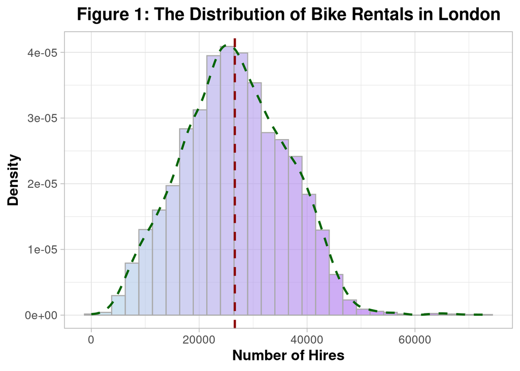

```r
# Plotting a histogram with a density plot for the distribution of bike hires
ggplot(datasetBikeHires, aes(x = Hires, y = ..density..)) +
  geom_histogram(aes(fill = ..x..), alpha = 0.6, color = "darkgrey") +
  scale_fill_gradient(low = "lightblue", high = "purple") +
  geom_density(color = "darkgreen", linewidth = 1, linetype = "dashed") +
  geom_vline(data = summaryBikeHires, aes(xintercept = meanHires), color = "darkred", linetype = "dashed", linewidth = 1) +
  labs(title = "Figure 1: The Distribution of Bike Rentals in London", x = "Number of Hires", y = "Density") +
  theme_light(base_size = 14) +
  theme(plot.title = element_text(hjust = 0.5, face = "bold"),
        axis.title = element_text(face = "bold"),
        legend.position = "none")
```

The dotted red line represents the mean of the distribution.

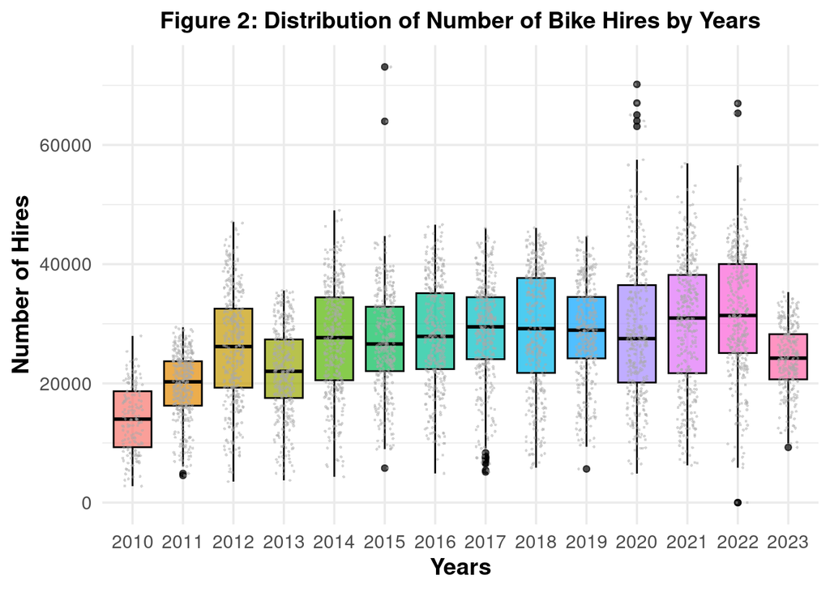

```r
# Creating a boxplot to visualise the distribution of the number of bike hires by year
ggplot(datasetBikeHires, aes(x = factor(year), y = Hires)) + # Year-based fill color,
  geom_boxplot(aes(fill = factor(year)), alpha = 0.7, color = "black") +
  geom_jitter(shape = 16, color = "darkgray", size = 0.5, width = 0.2, alpha = 0.5) + # Jittered points to show individual hire data,
  labs(title = "Figure 2: Distribution of Number of Bike Hires by Years",
       x = "Years",
       y = "Number of Hires") +
  theme_minimal(base_size = 14) +
  theme(plot.title = element_text(size = 14, face = "bold", hjust = 0.5),
        axis.title.x = element_text(face = "bold"),
        axis.title.y = element_text(face = "bold"),
        legend.position = "none")
```

These visualisations offer a detailed look at the pattern of bike hires throughout the dataset’s timeline. A signficant rightward skew in Figure 1 points to occasional spikes in bicycle rentals, though these spikes are not typical. The detection of outliers within the data suggests specific occasions or events, such as rail strikes in central London that force individuals to commute by bike, might trigger these unusual spikes in rental activity.

```r
# Filtering out the potential outliers. These are any observations from the dataset that fall outside the range of more than 2 standard deviations from the mean value
datasetBikeHiresNoOutliers <- datasetBikeHires %>% group_by(year) %>% filter(Hires <= (mean(Hires) +2*sd(Hires)) & Hires >= (mean(Hires)-2*sd(Hires)))
```

These are the new visualised distributions of Bike Hires after removing the outliers.

```r
summaryBikeHiresNoOutliers <- datasetBikeHiresNoOutliers %>% group_by(month, year) %>% summarise(meanHiresNoOutliers = mean(Hires))
summaryBikeHiresNoOutliers
```

```
##   meanHiresNoOutliers
## 1            26932.49
```

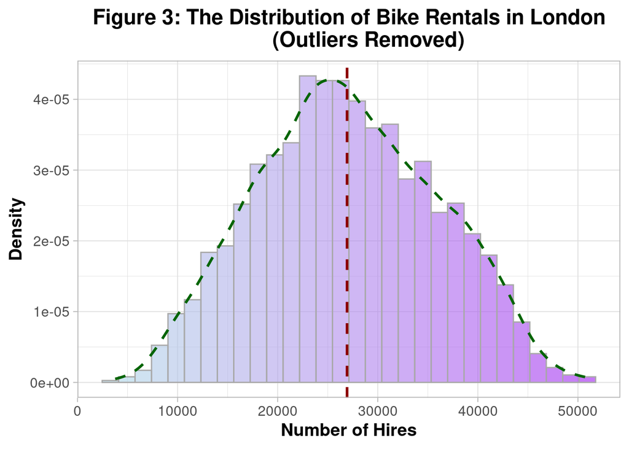

```r
ggplot(datasetBikeHiresNoOutliers, aes(x = Hires, y = ..density..)) +
  geom_histogram(aes(fill = ..x..), alpha = 0.6, color = "darkgrey") +
  scale_fill_gradient(low = "lightblue", high = "purple") +
  geom_density(color = "darkgreen", linewidth = 1, linetype = "dashed") +
  geom_vline(data = summaryBikeHiresNoOutliers, aes(xintercept = meanHiresNoOutliers), color = "darkred", linetype = "dashed", linewidth = 1) +
  labs(title = "Figure 3: The Distribution of Bike Rentals in London
       (Outliers Removed)", x = "Number of Hires", y = "Density") +
  theme_light(base_size = 14) +
  theme(plot.title = element_text(hjust = 0.5, face = "bold"),
        axis.title = element_text(face = "bold"),
        legend.position = "none")
```

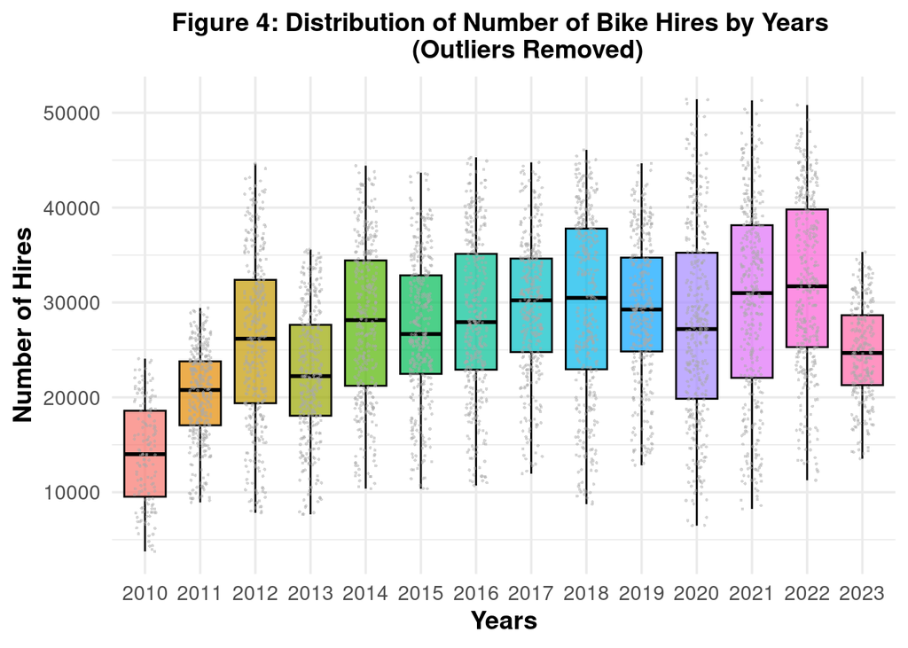

```r
ggplot(datasetBikeHiresNoOutliers, aes(x = factor(year), y = Hires)) +
  geom_boxplot(aes(fill = factor(year)), alpha = 0.7, color = "black") +
  geom_jitter(shape = 16, color = "darkgray", size = 0.5, width = 0.2, alpha = 0.5) +
  labs(title = "Figure 4: Distribution of Number of Bike Hires by Years
       (Outliers Removed)",
       x = "Years",
       y = "Number of Hires") +
  theme_minimal(base_size = 14) +
  theme(plot.title = element_text(size = 14, face = "bold", hjust = 0.5),
        axis.title.x = element_text(face = "bold"),
        axis.title.y = element_text(face = "bold"),
        legend.position = "none")
```

### Observations

The average monthly bike rentals for each year will be checked order to identify any clear annual patterns.

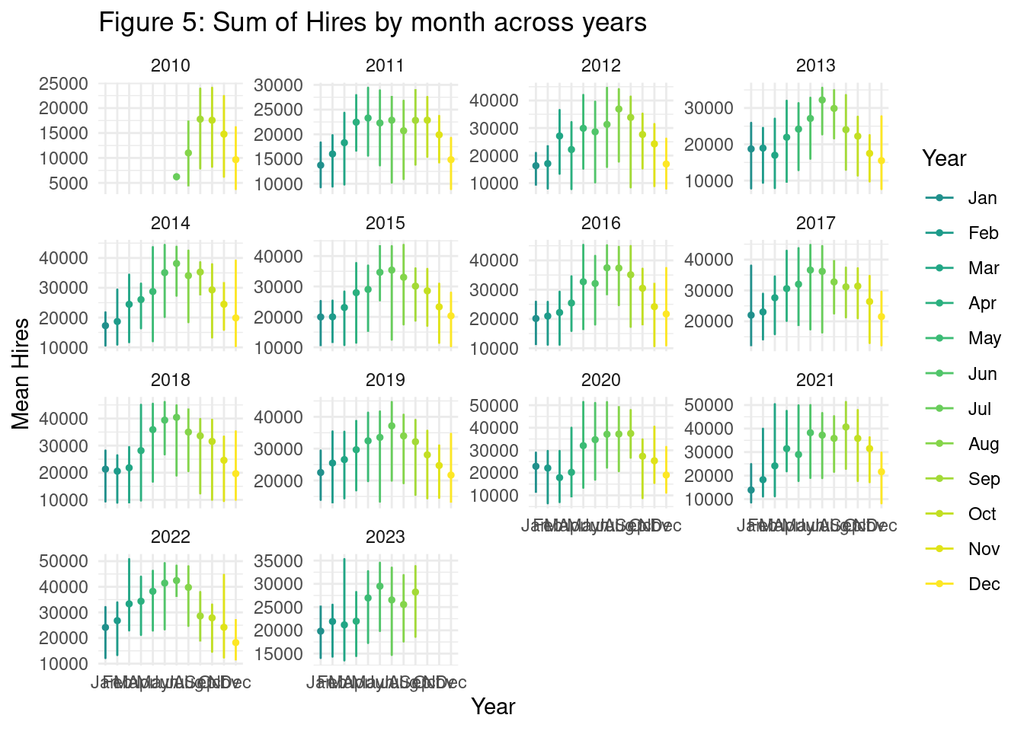

```r
# Adding levels for all months to arrange them chronologically

months = c("Jan","Feb","Mar","Apr","May","Jun","Jul","Aug","Sep","Oct","Nov","Dec")
datasetBikeHiresNoOutliers <- datasetBikeHiresNoOutliers %>% mutate(month = factor(month, levels = months))

# Adding levels for all weekdays
datasetBikeHiresNoOutliers <- datasetBikeHiresNoOutliers %>% mutate(day = factor(day, levels =c ("Mon", "Tue", "Wed","Thu", "Fri", "Sat", "Sun")))

# Plotting the distribution of bike hires for each month across years
datasetBikeHiresByMonth <- datasetBikeHiresNoOutliers %>% group_by(month, year)

ggplot(datasetBikeHiresByMonth, aes(x = month, y = Hires, group = interaction(month, year), color = month)) +
  geom_line(position = position_dodge(width = 0.3)) +
  stat_summary(fun = "mean", geom = "point", size = 1, position = position_dodge(width = 0.2)) +
  scale_color_viridis_d(begin = 0.5, end = 1, name = "Year") +
  labs(title = "Figure 5: Sum of Hires by month across years", x = "Year", y = "Mean Hires", color = "Year") +
  theme_minimal() +
  facet_wrap(~ year, scales = "free_y", ncol = 4)
```

Figure 5 displays the monthly bike hire patterns across various years, revealing a seasonal trend where hires typically surge in May, June, and July, before declining to annual lows from November to February. This suggests weather conditions and outdoor activity preferences significantly impact bike rental volumes. The year 2010 is an anomaly, exhibiting much lower hire rates throughout the year, and also containing incomplete data.

The data also shows deviations from established patterns, particularly in 2020 due to the emergence of COVID-19. Despite expectations for an increase, bike hires fell in March as restrictions were introduced. However, from April to May, hires rose sharply as ‘Stay at home’ orders were lifted, continuing to increase linearly through July as restrictions eased, except for work from home mandates. This upward trend stalled from July to September, then sharply declined as work from home and other COVID-19 restrictions were reinstated.

In the years following 2022, with most COVID-19 restrictions relaxed except for work from home, the bike hire landscape shifted again. Specifically, in 2023, there was a noticeable dip in hires during the summer months compared to previous years, potentially due to incomplete data.

## Analysis

Dividing the data into two segments, before and after lockdown, will allow us to check the monthly trends in bike hires.

```r
#Creating a variable to flag whether a record is BeforeCovid or during COVID
datasetBikeHiresNoOutliers <- datasetBikeHiresNoOutliers %>% mutate(COVIDIndicator=ifelse(year<"2020", "BeforeCovid","DuringCOVID"))
```

Comparing bike hires before and during COVID using emmeans and contrast

```r
# Adding labels to correctly display the sequence of 'Before COVID' and 'COVID' data points on the chart.
COVIDIndicatorLabels <- c("BeforeCovid","DuringCOVID")
  datasetBikeHiresNoOutliers$COVIDIndicator <- factor(datasetBikeHiresNoOutliers$COVIDIndicator, levels = COVIDIndicatorLabels)

# Utilizing the 'lm' function for linear modeling and 'emmeans' for estimating confidence intervals, alongside 'confint' for checking differences, to analyse bike hire trends before and during COVID years.

modelBikeHiresAcrossTime <- lm(Hires~COVIDIndicator, data=datasetBikeHiresNoOutliers)
( modelBikeHiresAcrossTime.emm <- emmeans(modelBikeHiresAcrossTime, ~COVIDIndicator)  )
```

```
##  COVIDIndicator emmean  SE   df lower.CL upper.CL
##  BeforeCovid     26178 154 4635    25875    26481
##  DuringCOVID     28830 245 4635    28351    29310
##
## Confidence level used: 0.95
```

```r
(  modelBikeHiresAcrossTime.contrast <- confint(pairs(modelBikeHiresAcrossTime.emm))  )
```

```
##  contrast                  estimate  SE   df lower.CL upper.CL
##  BeforeCovid - DuringCOVID    -2652 289 4635    -3220    -2085
##
## Confidence level used: 0.95
```

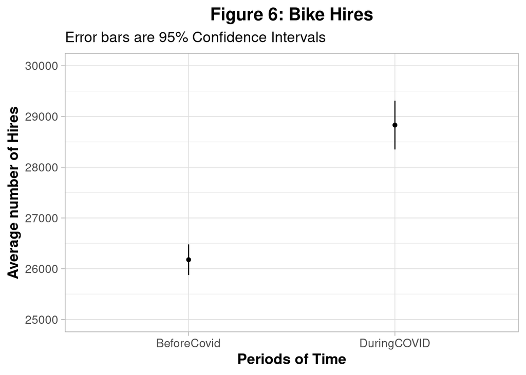

```r
# Plotting the average number of bike hires for the periods before and during COVID years.

ggplot(summary(modelBikeHiresAcrossTime.emm), aes(x=COVIDIndicator, y=emmean, ymin=lower.CL, ymax=upper.CL)) + geom_point() + geom_linerange() +
labs(y="Average number of Hires", x="Periods of Time", subtitle="Error bars are 95% Confidence Intervals", title="Figure 6: Bike Hires") + ylim(25000,30000) + theme_light(base_size = 14) +
  theme(plot.title = element_text(hjust = 0.5, face = "bold"),
        axis.title = element_text(face = "bold"),
        legend.position = "none")
```

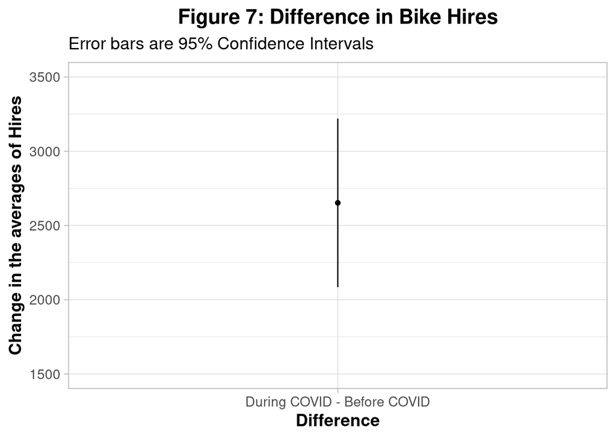

```r
# Plotting the difference in the average number of bike hires for the periods before and during COVID years.

ggplot(modelBikeHiresAcrossTime.contrast, aes(x=contrast, y=-estimate, ymin=-lower.CL, ymax=-upper.CL)) +
 geom_point() + geom_linerange() +
labs(y="Change in the averages of Hires", x="Difference", subtitle="Error bars are 95% Confidence Intervals", title="Figure 7: Difference in Bike Hires") +
scale_x_discrete(labels = c("During COVID - Before COVID")) + ylim(1500,3500)  + theme_light(base_size = 14) +
  theme(plot.title = element_text(hjust = 0.5, face = "bold"),
        axis.title = element_text(face = "bold"),
        legend.position = "none")
```

```r
#  Filter the dataset to include only records from the pre-COVID-19 era (2011-2019)
preCOVID19 <- datasetBikeHiresNoOutliers %>%
  filter(year %in% c(2011:2019))
# Filter the dataset to include only records during the COVID-19 era (2020-2023).
duringCOVID19 <- datasetBikeHiresNoOutliers %>%
  filter(year %in% c(2020:2023))
```

Conducting a t-test to confirm any statistically significant difference

```r
# two-sample t-test to compare bike hires before and during COVID
t.test(preCOVID19$Hires, duringCOVID19$Hires)
```

```
##
##  Welch Two Sample t-test
##
## data:  preCOVID19$Hires and duringCOVID19$Hires
## t = -6.92, df = 2215.2, p-value = 5.89e-12
## alternative hypothesis: true difference in means is not equal to 0
## 95 percent confidence interval:
##  -2662.126 -1486.473
## sample estimates:
## mean of x mean of y
##  26756.14  28830.44
```

## Correlation

Running correlation checks

```r
# Creating the correlation matrix
visualisedCorrMatrix <- rcorr(as.matrix(select_if(datasetBikeHiresNoOutliers, is.numeric)))
visualisedCorrMatrix
```

```
##                                 Hires schools_closed pubs_closed shops_closed
## Hires                            1.00          -0.12       -0.10        -0.11
## schools_closed                  -0.12           1.00        0.71         0.74
## pubs_closed                     -0.10           0.71        1.00         0.95
## shops_closed                    -0.11           0.74        0.95         1.00
## eating_places_closed            -0.10           0.71        1.00         0.95
## stay_at_home                    -0.16           0.71        0.84         0.89
## household_mixing_indoors_banned -0.08           0.62        0.87         0.83
## wfh                              0.06           0.30        0.43         0.40
## rule_of_6_indoors                0.12          -0.02       -0.03        -0.03
## curfew                           0.00          -0.02       -0.03        -0.02
## eat_out_to_help_out              0.08          -0.01       -0.02        -0.02
## year                             0.29           0.16        0.23         0.22
##                                 eating_places_closed stay_at_home
## Hires                                          -0.10        -0.16
## schools_closed                                  0.71         0.71
## pubs_closed                                     1.00         0.84
## shops_closed                                    0.95         0.89
## eating_places_closed                            1.00         0.84
## stay_at_home                                    0.84         1.00
## household_mixing_indoors_banned                 0.87         0.74
## wfh                                             0.43         0.36
## rule_of_6_indoors                              -0.03        -0.03
## curfew                                         -0.03        -0.02
## eat_out_to_help_out                            -0.02        -0.02
## year                                            0.23         0.19
##                                 household_mixing_indoors_banned   wfh
## Hires                                                     -0.08  0.06
## schools_closed                                             0.62  0.30
## pubs_closed                                                0.87  0.43
## shops_closed                                               0.83  0.40
## eating_places_closed                                       0.87  0.43
## stay_at_home                                               0.74  0.36
## household_mixing_indoors_banned                            1.00  0.49
## wfh                                                        0.49  1.00
## rule_of_6_indoors                                         -0.04  0.24
## curfew                                                     0.24  0.21
## eat_out_to_help_out                                       -0.02 -0.04
## year                                                       0.26  0.70
##                                 rule_of_6_indoors curfew eat_out_to_help_out
```

[output cut: 80 more lines]

```
## eat_out_to_help_out             0.4528            0.5574
## year                            0.0000            0.0000 0.0000
##                                 year
## Hires                           0.0000
## schools_closed                  0.0000
## pubs_closed                     0.0000
## shops_closed                    0.0000
## eating_places_closed            0.0000
## stay_at_home                    0.0000
## household_mixing_indoors_banned 0.0000
## wfh                             0.0000
## rule_of_6_indoors               0.0000
## curfew                          0.0000
## eat_out_to_help_out             0.0000
## year
```

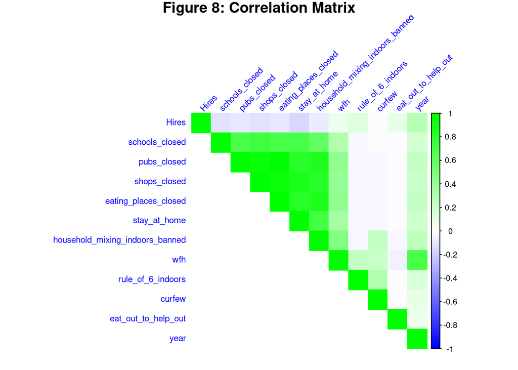

```r
# Graphically plotting the correlation matrix for easier interpretation

corrplot(visualisedCorrMatrix$r, method = "color",
         type = "upper", # Displaying only the upper half of the matrix
         tl.col = "blue",
         tl.srt = 45, # Rotating text labels to 45 degrees for an easier read
         col = colorRampPalette(c("blue", "white", "green"))(100),
         main = "Figure 8: Correlation Matrix", # Title of the plot
         mar = c(1, 1, 1, 1), # Set even margins around the plot
         tl.cex = 0.7,
         cl.cex = 0.65,
         tl.pos = "lt"
)
```

The analysis shows that various pandemic-related measures—‘schools_closed’, ‘pubs_closed’, ‘shops_closed’, ‘eating_places_closed’, ‘stay_at_home’, and ‘household_mixing_indoors_banned’—are highly correlated with one another.

Furthermore, ‘Rule_of_6_indoors’ exhibits a significant positive correlation with bike hires, indicated by a collinearity value of 0.12 and a p-value of less than 0.05, marking it as statistically significant. ‘Eat_out_to_help_out’ also shows a positive link with hires, evidenced by a collinearity of 0.08 and a p-value of less than 0.05, again highlighting its statistical significance. The wfh policy similarly correlates positively with the number of hires, with a collinearity of 0.06 and a p-value of less than 0.05, indicating its statistical significance.

Contrastingly, there is a negative correlation between ‘eat_out_to_help_out’ and ‘work from home’ policies, as the collinearity is -0.04 with a p-value of less than 0.05, making this correlation statistically significant. However, the relationship between ‘rule_of_6_indoors’ and ‘eat_out_to_help_out’ is negatively correlated with a collinearity of -0.01 and a p-value of 0.45, suggesting this correlation is not statistically significant.

Lastly, a positive correlation exists between ‘rule_of_6_indoors’ and ‘work from home’ policies, shown by a collinearity of 0.24 and a p-value of less than 0.05, confirming its statistical significance.

Next, we will plot the relationship between each policy and the number of bike hires.

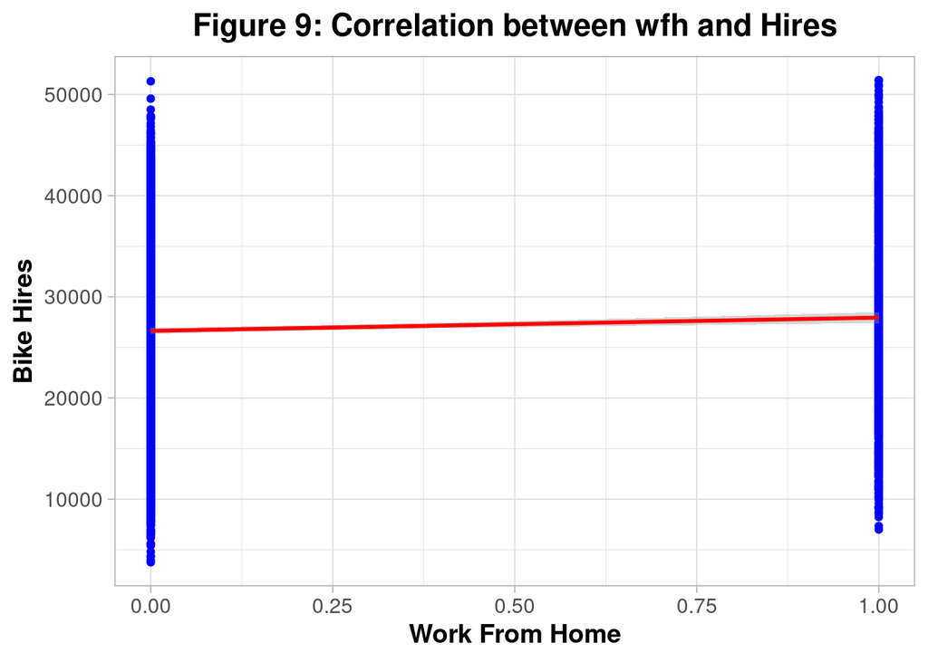

```r
ggplot(datasetBikeHiresNoOutliers, aes(y = Hires, x = wfh)) +
    geom_point(color = "blue") +
    geom_smooth(method = lm, color = "red") +
    labs(x = "Work From Home", y = "Bike Hires", title = "Figure 9: Correlation between wfh and Hires") + theme_light(base_size = 14) +
  theme(plot.title = element_text(hjust = 0.5, face = "bold"),
        axis.title = element_text(face = "bold"),
        legend.position = "none")
```

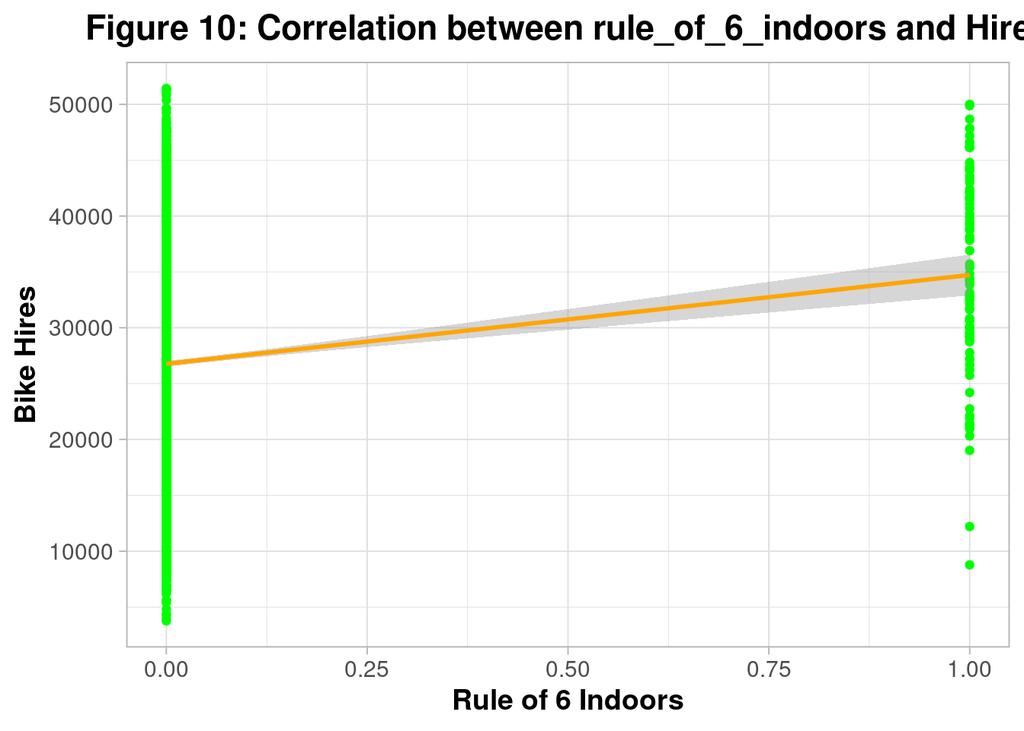

```r
ggplot(datasetBikeHiresNoOutliers, aes(y = Hires, x = rule_of_6_indoors)) +
    geom_point(color = "green") +
    geom_smooth(method = lm, color = "orange") +
    labs(x = "Rule of 6 Indoors", y = "Bike Hires", title = "Figure 10: Correlation between rule_of_6_indoors and Hires") + theme_light(base_size = 14) +
  theme(plot.title = element_text(hjust = 0.5, face = "bold"),
        axis.title = element_text(face = "bold"),
        legend.position = "none")
```

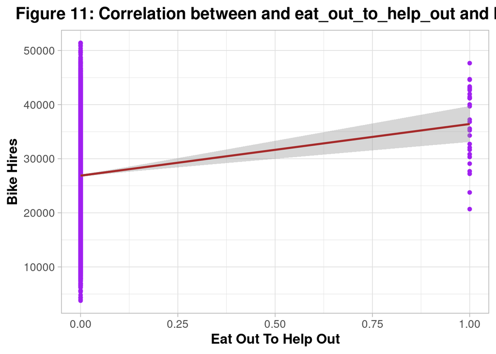

```r
ggplot(datasetBikeHiresNoOutliers, aes(y = Hires, x = eat_out_to_help_out)) +
    geom_point(color = "purple") +
    geom_smooth(method = lm, color = "brown") +
    labs(x = "Eat Out To Help Out", y = "Bike Hires",title = "Figure 11: Correlation between and eat_out_to_help_out and Hires") + theme_light(base_size = 14) +
  theme(plot.title = element_text(hjust = 0.5, face = "bold"),
        axis.title = element_text(face = "bold"),
        legend.position = "none")
```

## Modelling

### Eat_Out_To_Help_Out, Work From Home and Rule_of_6_Indoors

We will explore the effect of the above 3 COVID-19 policies on Bike Hires using Regression Analysis

```r
# Linear regression model on the new dataset only containing data from 2014 to 2023 for all of the combined relevant policies 'wfh', 'rule of 6 indoors' and 'eat out to help out'

modelCovidPolicies <- lm(Hires ~ wfh + rule_of_6_indoors + eat_out_to_help_out, datasetBikeHiresNoOutliers)
summary(modelCovidPolicies)
```

```
##
## Call:
## lm(formula = Hires ~ wfh + rule_of_6_indoors + eat_out_to_help_out,
##     data = datasetBikeHiresNoOutliers)
##
## Residuals:
##      Min       1Q   Median       3Q      Max
## -26006.8  -6402.1   -351.1   6537.1  24753.1
##
## Coefficients:
##                     Estimate Std. Error t value Pr(>|t|)
## (Intercept)          26546.9      148.5 178.781  < 2e-16 ***
## wfh                    799.2      321.1   2.489   0.0128 *
## rule_of_6_indoors     7439.7      966.0   7.702 1.63e-14 ***
## eat_out_to_help_out   9871.5     1681.9   5.869 4.69e-09 ***
## ---
## Signif. codes:  0 '***' 0.001 '**' 0.01 '*' 0.05 '.' 0.1 ' ' 1
##
## Residual standard error: 8865 on 4633 degrees of freedom
## Multiple R-squared:  0.02344,    Adjusted R-squared:  0.02281
## F-statistic: 37.08 on 3 and 4633 DF,  p-value: < 2.2e-16
```

```r
confint(modelCovidPolicies)
```

```
##                          2.5 %    97.5 %
## (Intercept)         26255.8399 26838.057
## wfh                   169.7602  1428.585
## rule_of_6_indoors    5545.9049  9333.396
## eat_out_to_help_out  6574.1000 13168.861
```

Similarly, ‘eat out to help out’ significantly boosts bike rentals, with a t-value of 5.87 (p < .001) and each unit increase predicting an average jump of 9871.5 in rentals (95% CI = [6574,13168]).

```r
datasetBikeHiresNoOutliersLimited <- datasetBikeHiresNoOutliers %>%
  filter(year %in% c(2014:2023))
```

```r
# Linear regression model on the new dataset only containing data from 2014 to 2023 for all of the combined relevant policies 'wfh', 'rule of 6 indoors' and 'eat out to help out'.
modelTestBikeHiresLimited <- lm(Hires ~ wfh + rule_of_6_indoors + eat_out_to_help_out, datasetBikeHiresNoOutliersLimited)
summary(modelTestBikeHiresLimited)
```

```
##
## Call:
## lm(formula = Hires ~ wfh + rule_of_6_indoors + eat_out_to_help_out,
##     data = datasetBikeHiresNoOutliersLimited)
##
## Residuals:
##      Min       1Q   Median       3Q      Max
## -25823.6  -5728.9   -178.1   6287.6  24059.9
##
## Coefficients:
##                     Estimate Std. Error t value Pr(>|t|)
## (Intercept)          28943.6      176.3 164.205  < 2e-16 ***
## wfh                  -1581.5      326.3  -4.847 1.31e-06 ***
## rule_of_6_indoors     7240.5      932.8   7.762 1.09e-14 ***
## eat_out_to_help_out   7474.8     1627.3   4.593 4.52e-06 ***
## ---
## Signif. codes:  0 '***' 0.001 '**' 0.01 '*' 0.05 '.' 0.1 ' ' 1
##
## Residual standard error: 8560 on 3427 degrees of freedom
## Multiple R-squared:  0.02653,    Adjusted R-squared:  0.02568
## F-statistic: 31.13 on 3 and 3427 DF,  p-value: < 2.2e-16
```

```r
confint(modelTestBikeHiresLimited)
```

```
##                         2.5 %     97.5 %
## (Intercept)         28598.032 29289.2234
## wfh                 -2221.249  -941.7166
## rule_of_6_indoors    5411.685  9069.3144
## eat_out_to_help_out  4284.271 10665.3307
```

The positive impact of ‘rule_of_6_indoors’ and ‘eat_out_to_help_out’ on bike rentals continues, indicating a stable relationship over the years, despite potential adversity. Focusing more on the period around and after COVID-19, and considering the rise of technology, the analysis now reveals a significant negative influence of working from home (wfh) on rentals. With a t-value of -4.847 (p < .001), each increase in wfh predicts a reduction of 1582 in bike rentals, with a 95% confidence interval between -2221 and -942, showing statistical significance not seen in earlier data.

```r
anova(modelTestBikeHiresLimited)
```

```
## Analysis of Variance Table
##
## Response: Hires
##                       Df     Sum Sq    Mean Sq F value    Pr(>F)
## wfh                    1 8.9141e+08  891408846  12.165  0.000493 ***
## rule_of_6_indoors      1 4.4064e+09 4406380585  60.135 1.160e-14 ***
## eat_out_to_help_out    1 1.5461e+09 1546078582  21.100 4.517e-06 ***
## Residuals           3427 2.5111e+11   73274840
## ---
## Signif. codes:  0 '***' 0.001 '**' 0.01 '*' 0.05 '.' 0.1 ' ' 1
```

```r
# Using the multiple regression with the interaction term on the new dataset

modelCovidPoliciesInteraction <- lm(Hires ~ wfh * rule_of_6_indoors * eat_out_to_help_out, datasetBikeHiresNoOutliersLimited)
summary(modelCovidPoliciesInteraction)
```

```
##
## Call:
## lm(formula = Hires ~ wfh * rule_of_6_indoors * eat_out_to_help_out,
##     data = datasetBikeHiresNoOutliersLimited)
##
## Residuals:
##      Min       1Q   Median       3Q      Max
## -25394.6  -5729.3   -168.7   6279.2  24022.3
##
## Coefficients: (3 not defined because of singularities)
##                                           Estimate Std. Error t value Pr(>|t|)
## (Intercept)                                28928.3      176.5 163.937  < 2e-16
## wfh                                        -1528.6      327.8  -4.664 3.22e-06
## rule_of_6_indoors                          12404.3     3239.4   3.829 0.000131
## eat_out_to_help_out                         7490.1     1626.9   4.604 4.30e-06
## wfh:rule_of_6_indoors                      -5630.3     3382.6  -1.665 0.096100
## wfh:eat_out_to_help_out                         NA         NA      NA       NA
## rule_of_6_indoors:eat_out_to_help_out           NA         NA      NA       NA
## wfh:rule_of_6_indoors:eat_out_to_help_out       NA         NA      NA       NA
##
## (Intercept)                               ***
## wfh                                       ***
## rule_of_6_indoors                         ***
## eat_out_to_help_out                       ***
## wfh:rule_of_6_indoors                     .
## wfh:eat_out_to_help_out
## rule_of_6_indoors:eat_out_to_help_out
## wfh:rule_of_6_indoors:eat_out_to_help_out
## ---
## Signif. codes:  0 '***' 0.001 '**' 0.01 '*' 0.05 '.' 0.1 ' ' 1
##
## Residual standard error: 8558 on 3426 degrees of freedom
## Multiple R-squared:  0.02732,    Adjusted R-squared:  0.02618
## F-statistic: 24.05 on 4 and 3426 DF,  p-value: < 2.2e-16
```

```r
confint(modelCovidPoliciesInteraction)
```

```
##                                                2.5 %     97.5 %
## (Intercept)                                28582.327 29274.2826
## wfh                                        -2171.245  -885.9943
## rule_of_6_indoors                           6052.959 18755.5737
## eat_out_to_help_out                         4300.367 10679.8809
## wfh:rule_of_6_indoors                     -12262.387  1001.6975
## wfh:eat_out_to_help_out                           NA         NA
## rule_of_6_indoors:eat_out_to_help_out             NA         NA
## wfh:rule_of_6_indoors:eat_out_to_help_out         NA         NA
```

The analysis reveals significant positive effects from ‘eat_out_to_help_out’ (CI = [4300, 10680], t = 4.60, p < 0.001), ‘rule_of_6_indoors’ (CI = [6053, 18756], t = 3.83, p < 0.001), and significant negative effects due to ‘wfh’ (CI = [-2171, -886], t = -4.66, p < 0.001). However, the negative interaction between ‘wfh’ and ‘rule_of_6_indoors’ (CI = [-12262, 1002], t = -1.67) was not statistically significant (p > 0.001).

No interactions were found between ‘eat_out_to_help_out’ and ‘rule_of_6_indoors’, ‘eat_out_to_help_out’ and ‘wfh’, or among all three factors combined. A VIF test will be conducted to ensure low risk of variable correlation.

```r
#Another further check for multicollinearity
VIFTest <- vif(modelTestBikeHiresLimited)
VIFTest
```

```
##                 wfh   rule_of_6_indoors eat_out_to_help_out
##            1.055400            1.051838            1.003615
```

The VIF analysis presents values close to 1 for all variables, showing minimal risk of multicollinearity within the model. Typically, multicollinearity becomes a concern when VIF values rise above 5 or 10.

### Days, Months, Years

We shall now explore controlling the time variables : Days, Months and Years

```r
# Linear regression of each policy with all the following: years, months and days

#WFH
modelHiresWFH <- lm(Hires ~ wfh + day + month + year, data = datasetBikeHiresNoOutliers)
summary(modelHiresWFH)
```

```
##
## Call:
## lm(formula = Hires ~ wfh + day + month + year, data = datasetBikeHiresNoOutliers)
##
## Residuals:
##      Min       1Q   Median       3Q      Max
## -23785.4  -3967.4    318.9   3783.4  28344.6
##
## Coefficients:
##               Estimate Std. Error t value Pr(>|t|)
## (Intercept) -2.302e+06  6.852e+04 -33.588  < 2e-16 ***
## wfh         -6.308e+03  3.120e+02 -20.218  < 2e-16 ***
## dayTue       2.090e+03  3.416e+02   6.120 1.02e-09 ***
## dayWed       2.117e+03  3.413e+02   6.201 6.09e-10 ***
## dayThu       2.029e+03  3.414e+02   5.942 3.03e-09 ***
## dayFri       1.025e+03  3.414e+02   3.003  0.00269 **
## daySat      -1.725e+03  3.468e+02  -4.973 6.84e-07 ***
## daySun      -3.215e+03  3.480e+02  -9.239  < 2e-16 ***
## monthFeb     1.290e+03  4.662e+02   2.767  0.00568 **
## monthMar     4.278e+03  4.559e+02   9.382  < 2e-16 ***
## monthApr     7.533e+03  4.565e+02  16.503  < 2e-16 ***
## monthMay     1.142e+04  4.526e+02  25.225  < 2e-16 ***
## monthJun     1.437e+04  4.574e+02  31.425  < 2e-16 ***
## monthJul     1.581e+04  4.529e+02  34.907  < 2e-16 ***
## monthAug     1.220e+04  4.458e+02  27.359  < 2e-16 ***
## monthSep     1.160e+04  4.472e+02  25.947  < 2e-16 ***
## monthOct     9.097e+03  4.513e+02  20.158  < 2e-16 ***
## monthNov     4.771e+03  4.561e+02  10.461  < 2e-16 ***
## monthDec     1.124e+01  4.652e+02   0.024  0.98072
## year         1.151e+03  3.400e+01  33.863  < 2e-16 ***
## ---
## Signif. codes:  0 '***' 0.001 '**' 0.01 '*' 0.05 '.' 0.1 ' ' 1
##
## Residual standard error: 6272 on 4617 degrees of freedom
## Multiple R-squared:  0.5128, Adjusted R-squared:  0.5108
## F-statistic: 255.8 on 19 and 4617 DF,  p-value: < 2.2e-16
```

```r
confint(modelHiresWFH)
```

```
##                     2.5 %        97.5 %
## (Intercept) -2435905.1013 -2167224.2939
## wfh            -6919.4487    -5696.1624
## dayTue          1420.6215     2759.9082
## dayWed          1447.4638     2785.7250
## dayThu          1359.4019     2698.1799
## dayFri           355.8826     1694.6746
## daySat         -2404.5572    -1044.6900
## daySun         -3897.7558    -2533.2008
## monthFeb         376.0809     2203.9790
## monthMar        3383.8359     5171.4719
## monthApr        6638.0893     8427.8493
## monthMay       10529.7136    12304.3627
## monthJun       13478.0523    15271.6412
## monthJul       14920.3071    16695.9580
## monthAug       11323.6875    13071.7864
## monthSep       10726.6867    12480.1248
## monthOct        8212.6108     9982.1987
## monthNov        3876.7805     5664.9421
## monthDec        -900.7328      923.2126
## year            1084.5797     1217.8801
```

```r
modelHiresWFH_emm <- emmeans(modelHiresWFH, ~ wfh)
modelHiresWFH_emm
```

```
##  wfh emmean  SE   df lower.CL upper.CL
##    0  28102 116 4617    27874    28330
##    1  21794 259 4617    21287    22301
##
## Results are averaged over the levels of: day, month
## Confidence level used: 0.95
```

```r
(modelHiresWFH_contrast <- confint(pairs(modelHiresWFH_emm)))
```

```
##  contrast    estimate  SE   df lower.CL upper.CL
##  wfh0 - wfh1     6308 312 4617     5696     6919
##
## Results are averaged over the levels of: day, month
## Confidence level used: 0.95
```

```r
# Rule of 6 Indoor
modelHiresRuleof6Indoor <- lm(Hires ~ rule_of_6_indoors + day + month + year, data = datasetBikeHiresNoOutliers)
summary(modelHiresRuleof6Indoor)
```

```
##
## Call:
## lm(formula = Hires ~ rule_of_6_indoors + day + month + year,
##     data = datasetBikeHiresNoOutliers)
##
## Residuals:
##    Min     1Q Median     3Q    Max
## -24136  -4184    523   4469  26145
##
## Coefficients:
##                     Estimate Std. Error t value Pr(>|t|)
## (Intercept)       -1.330e+06  5.168e+04 -25.734  < 2e-16 ***
## rule_of_6_indoors  2.439e+02  7.119e+02   0.343  0.73190
## dayTue             2.063e+03  3.564e+02   5.790 7.50e-09 ***
## dayWed             2.086e+03  3.561e+02   5.857 5.04e-09 ***
## dayThu             1.997e+03  3.562e+02   5.606 2.19e-08 ***
## dayFri             9.880e+02  3.562e+02   2.774  0.00557 **
## daySat            -1.718e+03  3.619e+02  -4.747 2.13e-06 ***
## daySun            -3.238e+03  3.631e+02  -8.918  < 2e-16 ***
## monthFeb           1.311e+03  4.864e+02   2.696  0.00704 **
## monthMar           3.979e+03  4.754e+02   8.370  < 2e-16 ***
## monthApr           7.020e+03  4.755e+02  14.764  < 2e-16 ***
## monthMay           1.094e+04  4.723e+02  23.160  < 2e-16 ***
## monthJun           1.391e+04  4.796e+02  29.000  < 2e-16 ***
## monthJul           1.549e+04  4.732e+02  32.725  < 2e-16 ***
## monthAug           1.250e+04  4.649e+02  26.878  < 2e-16 ***
## monthSep           1.176e+04  4.674e+02  25.149  < 2e-16 ***
## monthOct           9.056e+03  4.720e+02  19.187  < 2e-16 ***
## monthNov           4.740e+03  4.758e+02   9.962  < 2e-16 ***
## monthDec          -3.384e+02  4.850e+02  -0.698  0.48543
## year               6.689e+02  2.562e+01  26.104  < 2e-16 ***
## ---
## Signif. codes:  0 '***' 0.001 '**' 0.01 '*' 0.05 '.' 0.1 ' ' 1
##
## Residual standard error: 6544 on 4617 degrees of freedom
## Multiple R-squared:  0.4697, Adjusted R-squared:  0.4675
## F-statistic: 215.2 on 19 and 4617 DF,  p-value: < 2.2e-16
```

```r
confint(modelHiresRuleof6Indoor)
```

```
##                          2.5 %        97.5 %
## (Intercept)       -1431376.362 -1228726.7637
## rule_of_6_indoors    -1151.810     1639.6588
## dayTue                1364.717     2762.0150
## dayWed                1387.488     2783.7112
## dayThu                1298.603     2695.3633
## dayFri                 289.663     1686.4312
## daySat               -2427.213    -1008.3623
## daySun               -3949.983    -2526.3278
## monthFeb               357.896     2264.9677
## monthMar              3047.371     4911.4652
## monthApr              6087.989     7952.3909
## monthMay             10011.987    11863.7536
## monthJun             12968.284    14848.8244
## monthJul             14557.912    16413.3528
## monthAug             11584.096    13406.9310
## monthSep             10838.690    12671.4345
## monthOct              8130.268     9980.8440
## monthNov              3807.315     5672.9824
## monthDec             -1289.228      612.4824
## year                   618.637      719.1046
```

```r
modelHiresRuleof6Indoor_emm <- emmeans(modelHiresRuleof6Indoor, ~ rule_of_6_indoors)
modelHiresRuleof6Indoor_emm
```

```
##  rule_of_6_indoors emmean    SE   df lower.CL upper.CL
##                  0  26672  97.2 4617    26482    26863
##                  1  26916 704.9 4617    25534    28298
##
## Results are averaged over the levels of: day, month
## Confidence level used: 0.95
```

```r
modelHiresRulesof6Indoor_contrast <- confint(pairs(modelHiresRuleof6Indoor_emm))
modelHiresRulesof6Indoor_contrast
```

```
##  contrast                                estimate  SE   df lower.CL upper.CL
##  rule_of_6_indoors0 - rule_of_6_indoors1     -244 712 4617    -1640     1152
##
## Results are averaged over the levels of: day, month
## Confidence level used: 0.95
```

```r
#Eat out to help out
modelHiresEatOut <- lm(Hires ~ eat_out_to_help_out + day + month + year, data = datasetBikeHiresNoOutliers)
summary(modelHiresEatOut)
```

```
##
## Call:
## lm(formula = Hires ~ eat_out_to_help_out + day + month + year,
##     data = datasetBikeHiresNoOutliers)
##
## Residuals:
##      Min       1Q   Median       3Q      Max
## -23984.5  -4186.8    511.5   4470.6  26161.3
##
## Coefficients:
##                       Estimate Std. Error t value Pr(>|t|)
## (Intercept)         -1.325e+06  5.122e+04 -25.863  < 2e-16 ***
## eat_out_to_help_out  2.736e+03  1.283e+03   2.132  0.03303 *
## dayTue               2.064e+03  3.562e+02   5.796 7.26e-09 ***
## dayWed               2.086e+03  3.559e+02   5.862 4.90e-09 ***
## dayThu               1.997e+03  3.561e+02   5.609 2.15e-08 ***
## dayFri               9.878e+02  3.561e+02   2.774  0.00556 **
## daySat              -1.721e+03  3.617e+02  -4.757 2.02e-06 ***
## daySun              -3.238e+03  3.629e+02  -8.923  < 2e-16 ***
## monthFeb             1.312e+03  4.861e+02   2.698  0.00700 **
## monthMar             3.979e+03  4.752e+02   8.374  < 2e-16 ***
## monthApr             7.020e+03  4.753e+02  14.771  < 2e-16 ***
## monthMay             1.095e+04  4.714e+02  23.223  < 2e-16 ***
## monthJun             1.393e+04  4.765e+02  29.229  < 2e-16 ***
## monthJul             1.550e+04  4.720e+02  32.832  < 2e-16 ***
## monthAug             1.231e+04  4.726e+02  26.052  < 2e-16 ***
## monthSep             1.176e+04  4.663e+02  25.228  < 2e-16 ***
## monthOct             9.063e+03  4.706e+02  19.256  < 2e-16 ***
## monthNov             4.738e+03  4.756e+02   9.962  < 2e-16 ***
## monthDec            -3.412e+02  4.848e+02  -0.704  0.48156
## year                 6.662e+02  2.539e+01  26.236  < 2e-16 ***
## ---
## Signif. codes:  0 '***' 0.001 '**' 0.01 '*' 0.05 '.' 0.1 ' ' 1
##
## Residual standard error: 6541 on 4617 degrees of freedom
## Multiple R-squared:  0.4702, Adjusted R-squared:  0.468
## F-statistic: 215.7 on 19 and 4617 DF,  p-value: < 2.2e-16
```

```r
confint(modelHiresEatOut)
```

```
##                             2.5 %        97.5 %
## (Intercept)         -1425061.5678 -1224237.6318
## eat_out_to_help_out      220.5525     5250.7095
## dayTue                  1366.0356     2762.6558
## dayWed                  1388.5237     2784.0707
## dayThu                  1299.1079     2695.1931
## dayFri                   289.7212     1685.8158
## daySat                 -2429.6780    -1011.5839
## daySun                 -3949.6252    -2526.6524
## monthFeb                 358.5376     2264.6949
## monthMar                3047.7388     4910.9392
## monthApr                6088.4973     7952.0054
## monthMay               10022.1944    11870.3804
## monthJun               12992.3288    14860.5152
## monthJul               14570.8169    16421.4198
## monthAug               11385.7438    13238.7972
## monthSep               10848.9895    12677.2146
## monthOct                8139.9468     9985.3062
## monthNov                3805.1453     5669.8740
## monthDec               -1291.5819      609.1694
## year                     616.4114      715.9739
```

```r
modelHiresEatOut_emm <- emmeans(modelHiresEatOut, ~ eat_out_to_help_out)
modelHiresEatOut_emm
```

```
##  eat_out_to_help_out emmean     SE   df lower.CL upper.CL
##                    0  26662   96.5 4617    26473    26851
##                    1  29397 1279.4 4617    26889    31906
##
## Results are averaged over the levels of: day, month
## Confidence level used: 0.95
```

```r
modelHiresEatOut_contrast <- confint(pairs(modelHiresEatOut_emm))
modelHiresEatOut_contrast
```

```
##  contrast                                    estimate   SE   df lower.CL
##  eat_out_to_help_out0 - eat_out_to_help_out1    -2736 1283 4617    -5251
##  upper.CL
##      -221
##
## Results are averaged over the levels of: day, month
## Confidence level used: 0.95
```

```r
# Comparing our pwith control for days
anova(modelHiresWFH)
```

```
## Analysis of Variance Table
##
## Response: Hires
##             Df     Sum Sq    Mean Sq  F value    Pr(>F)
## wfh          1 1.3805e+09 1.3805e+09   35.089 3.378e-09 ***
## day          6 1.4659e+10 2.4432e+09   62.100 < 2.2e-16 ***
## month       11 1.3006e+11 1.1823e+10  300.523 < 2.2e-16 ***
## year         1 4.5114e+10 4.5114e+10 1146.687 < 2.2e-16 ***
## Residuals 4617 1.8165e+11 3.9343e+07
## ---
## Signif. codes:  0 '***' 0.001 '**' 0.01 '*' 0.05 '.' 0.1 ' ' 1
```

```r
anova(modelHiresEatOut)
```

```
## Analysis of Variance Table
##
## Response: Hires
##                       Df     Sum Sq    Mean Sq F value    Pr(>F)
## eat_out_to_help_out    1 2.5348e+09 2.5348e+09  59.248 1.689e-14 ***
## day                    6 1.4700e+10 2.4501e+09  57.266 < 2.2e-16 ***
## month                 11 1.2864e+11 1.1694e+10 273.337 < 2.2e-16 ***
## year                   1 2.9449e+10 2.9449e+10 688.323 < 2.2e-16 ***
## Residuals           4617 1.9753e+11 4.2784e+07
## ---
## Signif. codes:  0 '***' 0.001 '**' 0.01 '*' 0.05 '.' 0.1 ' ' 1
```

```r
anova(modelHiresRuleof6Indoor)
```

```
## Analysis of Variance Table
##
## Response: Hires
##                     Df     Sum Sq    Mean Sq F value    Pr(>F)
## rule_of_6_indoors    1 5.6354e+09 5.6354e+09 131.592 < 2.2e-16 ***
## day                  6 1.4534e+10 2.4224e+09  56.565 < 2.2e-16 ***
## month               11 1.2578e+11 1.1435e+10 267.010 < 2.2e-16 ***
## year                 1 2.9182e+10 2.9182e+10 681.423 < 2.2e-16 ***
## Residuals         4617 1.9772e+11 4.2825e+07
## ---
## Signif. codes:  0 '***' 0.001 '**' 0.01 '*' 0.05 '.' 0.1 ' ' 1
```

```r
anova(modelHiresWFH,modelHiresEatOut,modelHiresRuleof6Indoor,modelCovidPolicies)
```

```
## Analysis of Variance Table
##
## Model 1: Hires ~ wfh + day + month + year
## Model 2: Hires ~ eat_out_to_help_out + day + month + year
## Model 3: Hires ~ rule_of_6_indoors + day + month + year
## Model 4: Hires ~ wfh + rule_of_6_indoors + eat_out_to_help_out
##   Res.Df        RSS  Df   Sum of Sq      F    Pr(>F)
## 1   4617 1.8165e+11
## 2   4617 1.9753e+11   0 -1.5888e+10
## 3   4617 1.9772e+11   0 -1.8952e+08
## 4   4633 3.6411e+11 -16 -1.6639e+11 264.33 < 2.2e-16 ***
## ---
## Signif. codes:  0 '***' 0.001 '**' 0.01 '*' 0.05 '.' 0.1 ' ' 1
```

```r
# Controling for days
modelHiresByDays <- lm(Hires ~ wfh + rule_of_6_indoors + eat_out_to_help_out + day, datasetBikeHiresNoOutliers)

# Controling for months
modelHiresByMonths <- lm(Hires ~ wfh + rule_of_6_indoors + eat_out_to_help_out + month, datasetBikeHiresNoOutliers)

# Controling for years
modelHiresByYears <- lm(Hires ~ wfh + rule_of_6_indoors + eat_out_to_help_out + factor(year), datasetBikeHiresNoOutliers)
```

```r
anova(modelCovidPolicies, modelHiresByDays)
```

```
## Analysis of Variance Table
##
## Model 1: Hires ~ wfh + rule_of_6_indoors + eat_out_to_help_out
## Model 2: Hires ~ wfh + rule_of_6_indoors + eat_out_to_help_out + day
##   Res.Df        RSS Df  Sum of Sq      F    Pr(>F)
## 1   4633 3.6411e+11
## 2   4627 3.4955e+11  6 1.4562e+10 32.127 < 2.2e-16 ***
## ---
## Signif. codes:  0 '***' 0.001 '**' 0.01 '*' 0.05 '.' 0.1 ' ' 1
```

```r
anova(modelCovidPolicies, modelHiresByMonths)
```

```
## Analysis of Variance Table
##
## Model 1: Hires ~ wfh + rule_of_6_indoors + eat_out_to_help_out
## Model 2: Hires ~ wfh + rule_of_6_indoors + eat_out_to_help_out + month
##   Res.Df        RSS Df  Sum of Sq      F    Pr(>F)
## 1   4633 3.6411e+11
## 2   4622 2.4237e+11 11 1.2175e+11 211.07 < 2.2e-16 ***
## ---
## Signif. codes:  0 '***' 0.001 '**' 0.01 '*' 0.05 '.' 0.1 ' ' 1
```

```r
anova(modelCovidPolicies, modelHiresByYears)
```

```
## Analysis of Variance Table
##
## Model 1: Hires ~ wfh + rule_of_6_indoors + eat_out_to_help_out
## Model 2: Hires ~ wfh + rule_of_6_indoors + eat_out_to_help_out + factor(year)
##   Res.Df        RSS Df  Sum of Sq      F    Pr(>F)
## 1   4633 3.6411e+11
## 2   4620 2.9231e+11 13 7.1803e+10 87.296 < 2.2e-16 ***
## ---
## Signif. codes:  0 '***' 0.001 '**' 0.01 '*' 0.05 '.' 0.1 ' ' 1
```

# Question 2

## Brief

The data provided contains information on e-book sales over a period of many months. Each row in the data represents one book. The values of the variables are taken across the entire time period, so daily.sales is the average number of sales (minus refunds) across all days in the period, and sale.price is the average price for which the book sold in the period.

## Data Dictionary

| Variable | Description |
| --- | --- |
| sold by | Platform where ebooks are sold |
| publisher.type | Publisher classification (e.g., Amazon, Big Five, indie)) |
| genre | Book genre (e.g., Adult Fiction, Non-Fiction, YA Fiction) |
| avg.review | Average review rating of the ebook (on a scale from 0 to 5) |
| daily.sales | Average daily sales (excluding refunds) over the period |
| sale.price | Average selling price of the ebook over the period |
| total.reviews | Total number of reviews received by the ebook |
| sale.price | Price at which the book was sold |

## Data Preparation

```r
# Reading the .csv datafile and importing it as 'datasetBooks'
datasetBooks <- read.csv("publisher_sales.csv", stringsAsFactors = TRUE)
```

```r
# Checking for any missing values
sum(is.na(datasetBooks))
```

```
## [1] 0
```

In this dataset, there are no missing values.

```r
# Checking for duplicate values
sum(duplicated(datasetBooks))
```

```
## [1] 0
```

In this dataset, there are no duplicate values. Check the structure and summary of the dataset,

```r
# Check the structure of the dataset
str(datasetBooks)
```

```
## 'data.frame':    6000 obs. of  7 variables:
##  $ sold.by       : Factor w/ 13 levels "Amazon Digital Services,  Inc.",..: 1 6 1 1 1 1 11 13 1 13 ...
##  $ publisher.type: Factor w/ 5 levels "amazon","big five",..: 3 2 5 5 5 5 2 2 5 2 ...
##  $ genre         : Factor w/ 3 levels "adult_fiction",..: 1 3 1 3 3 1 2 2 2 2 ...
##  $ avg.review    : num  4.5 4.64 2.5 4.5 4.98 3.98 4.62 3.5 4.64 4.56 ...
##  $ daily.sales   : num  84.4 113.1 70.8 149.4 135.7 ...
##  $ total.reviews : int  151 184 125 225 194 123 130 110 129 119 ...
##  $ sale.price    : num  5.12 6.91 6.27 4.91 7.39 ...
```

```r
# Printing the summary of the dataset
summary(datasetBooks)
```

```
##                                  sold.by           publisher.type
##  Amazon Digital Services,  Inc.      :4271   amazon       :  92
##  Random House LLC                    : 486   big five     :1688
##  Penguin Group (USA) LLC             : 346   indie        :1243
##  HarperCollins Publishers            : 274   single author: 789
##  Simon and Schuster Digital Sales Inc: 241   small/medium :2188
##  Macmillan                           : 172
##  (Other)                             : 210
##            genre        avg.review     daily.sales     total.reviews
##  adult_fiction:2000   Min.   :0.000   Min.   : -0.53   Min.   :  0.0
##  non_fiction  :2000   1st Qu.:4.090   1st Qu.: 64.22   1st Qu.:104.0
##  YA_fiction   :2000   Median :4.410   Median : 81.59   Median :128.0
##                       Mean   :4.269   Mean   : 86.37   Mean   :132.7
##                       3rd Qu.:4.610   3rd Qu.:104.73   3rd Qu.:163.0
##                       Max.   :4.980   Max.   :209.34   Max.   :243.0
##
##    sale.price
##  Min.   : 1.17
##  1st Qu.: 7.34
##  Median : 9.31
##  Mean   :10.30
##  3rd Qu.:13.58
##  Max.   :22.00
##
```

### Removing Outliers

The ‘daily.sales’ dataset contains negative values, which is not feasible since sales cannot be negative. Consequently, these records are considered outliers and must be removed.

```r
# Removing the 'daily.sales' outliers
datasetBooks <- datasetBooks %>% filter(daily.sales >= 0)
```

The ‘total.reviews’ and ‘avg.review’ variables include instances where the values are zero, despite potential sales occurring.

```r
# Removing the 'avg.review' and 'total.reviews' outliers
datasetBooks <- datasetBooks %>% filter(total.reviews >0, avg.review > 0)
```

These outliers could have distorted the overall performance analysis of our model, so it was important to eliminate them. Check the structure and summary of the dataset again after removal.

```r
# Checking the structure and summary of the dataset again after removing outliers.
str(datasetBooks)
```

```
## 'data.frame':    5976 obs. of  7 variables:
##  $ sold.by       : Factor w/ 13 levels "Amazon Digital Services,  Inc.",..: 1 6 1 1 1 1 11 13 1 13 ...
##  $ publisher.type: Factor w/ 5 levels "amazon","big five",..: 3 2 5 5 5 5 2 2 5 2 ...
##  $ genre         : Factor w/ 3 levels "adult_fiction",..: 1 3 1 3 3 1 2 2 2 2 ...
##  $ avg.review    : num  4.5 4.64 2.5 4.5 4.98 3.98 4.62 3.5 4.64 4.56 ...
##  $ daily.sales   : num  84.4 113.1 70.8 149.4 135.7 ...
##  $ total.reviews : int  151 184 125 225 194 123 130 110 129 119 ...
##  $ sale.price    : num  5.12 6.91 6.27 4.91 7.39 ...
```

```r
summary(datasetBooks)
```

```
##                                  sold.by           publisher.type
##  Amazon Digital Services,  Inc.      :4253   amazon       :  90
##  Random House LLC                    : 485   big five     :1682
##  Penguin Group (USA) LLC             : 344   indie        :1234
##  HarperCollins Publishers            : 272   single author: 788
##  Simon and Schuster Digital Sales Inc: 240   small/medium :2182
##  Macmillan                           : 172
##  (Other)                             : 210
##            genre        avg.review     daily.sales     total.reviews
##  adult_fiction:1993   Min.   :1.020   Min.   :  2.91   Min.   : 42.0
##  non_fiction  :1993   1st Qu.:4.100   1st Qu.: 64.20   1st Qu.:105.0
##  YA_fiction   :1990   Median :4.410   Median : 81.60   Median :128.0
##                       Mean   :4.286   Mean   : 86.37   Mean   :133.2
##                       3rd Qu.:4.610   3rd Qu.:104.74   3rd Qu.:164.0
##                       Max.   :4.980   Max.   :209.34   Max.   :243.0
##
##    sale.price
##  Min.   : 1.17
##  1st Qu.: 7.34
##  Median : 9.31
##  Mean   :10.30
##  3rd Qu.:13.59
##  Max.   :22.00
##
```

## Visualisations (Outliers)

We will start by visualising the dataset with respect to the dependant variable : daily sales.

```r
#Creating a duplicate dataset to not tamper with the original and maintain data integrity.
datasetBooksDuplicate <- datasetBooks

# Summarising daily sales statistics for the entire dataset
summaryDailySales <- summarise(datasetBooksDuplicate, meanDailySales = mean(daily.sales), standardDeviationDailySales = sd(daily.sales))
summaryDailySales
```

```
##   meanDailySales standardDeviationDailySales
## 1       86.36622                    30.20528
```

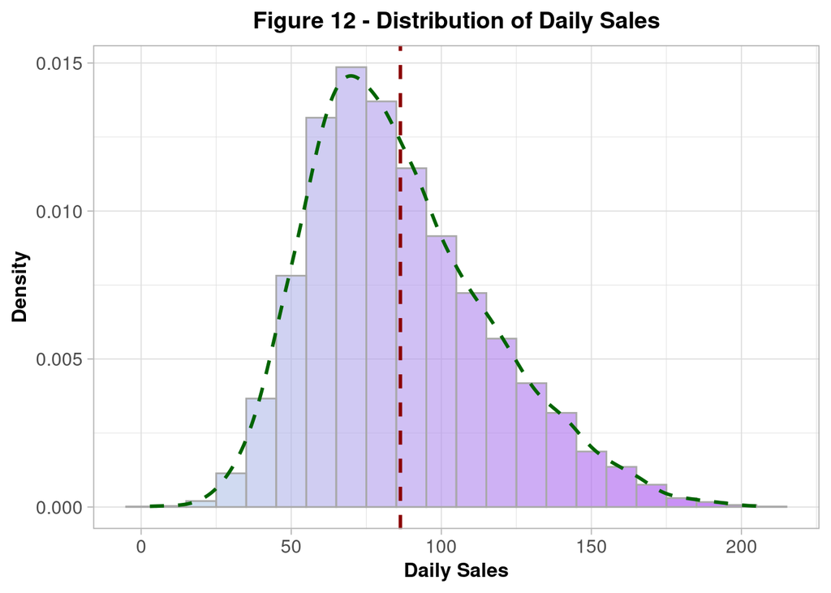

```r
# Creating a histogram and density plot to visualize the distribution of daily sales
ggplot(datasetBooksDuplicate, aes(x = daily.sales, y = ..density..)) +
  geom_histogram(aes(fill = ..x..), binwidth = 10, alpha = 0.6, color = "darkgrey") +
  scale_fill_gradient(low = "lightblue", high = "purple") +
  geom_density(color = "darkgreen", linewidth = 1, linetype = "dashed") +
  geom_vline(data = summaryDailySales, aes(xintercept = meanDailySales), color = "darkred", linetype = "dashed", linewidth = 1) +
  labs(title = "Figure 12 - Distribution of Daily Sales", x = "Daily Sales", y = "Density") +
  theme_light(base_size = 14) +
  theme(plot.title = element_text(size = 14, hjust = 0.5, face = "bold"),
        axis.title = element_text(size = 12, face = "bold"),
        legend.position = "none")
```

The distribution of daily sales is once more displayed in Figure 12, but this time the mean distribution—86.37—is indicated by the red dotted line. Since the dataset has a fairly distribution, it shouldn’t be necessary to remove any further outliers. This will be verified by comparing the statistical measures obtained before and after any prospective outliers have been removed.

```r
# Filtering out the potential outliers. These are any observations from the dataset that fall outside the range of more than 2 standard deviations from the mean value

datasetBooksNoOutliers <- datasetBooksDuplicate %>% filter(daily.sales <= (mean(daily.sales)+2*sd(daily.sales)) & daily.sales >= (mean(daily.sales)-2*sd(daily.sales)))

mean(datasetBooksNoOutliers$daily.sales)
```

```
## [1] 83.34014
```

```r
sd(datasetBooksNoOutliers$daily.sales)
```

```
## [1] 26.1452
```

The mean distribution without outliers is 83.34, which is similar to the mean of 86.37 including outliers. As there is neglible difference, these outliers will be kept. The standard deviation without outliers is also 26.1452, and as this is similar to the standard deviation with outliers (30.20528), they will be kept.

We will now visualise the dataset with respect to sale price.

```r
# Summarising sale price statistics for the entire dataset
summarySalePrice <- summarise(datasetBooksDuplicate, MeanSalePrice = mean(sale.price), StandardDeviationSalesPrice = sd(sale.price))
summarySalePrice
```

```
##   MeanSalePrice StandardDeviationSalesPrice
## 1      10.29841                    3.862718
```

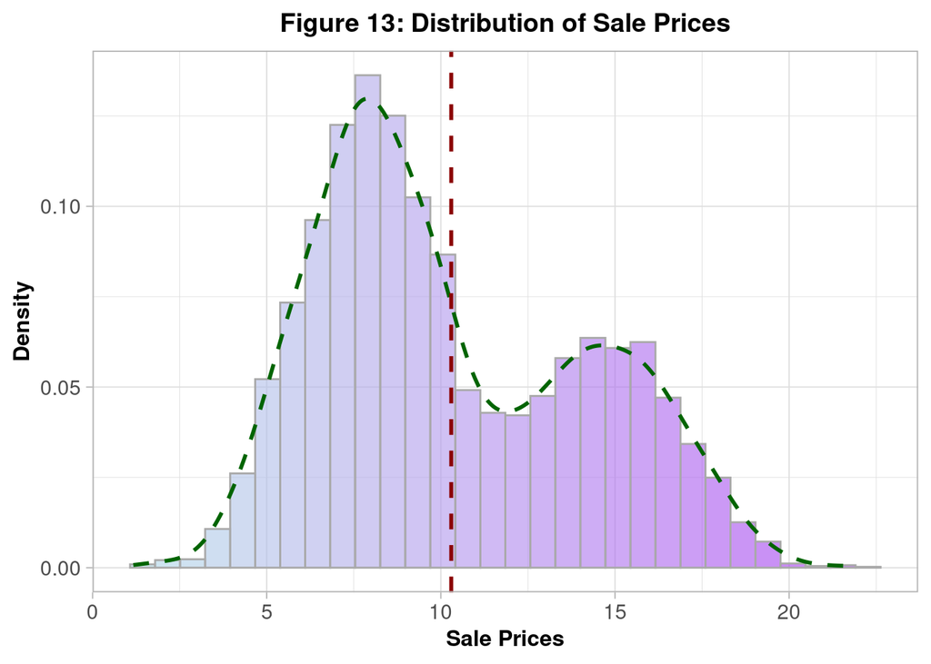

```r
# Making a histogram and density plot to visualise the distribution of sale prices
ggplot(datasetBooksDuplicate, aes(x = sale.price, y = ..density..)) +
  geom_histogram(aes(fill = ..x..), alpha = 0.6, color = "darkgrey") +
  scale_fill_gradient(low = "lightblue", high = "purple") +
  geom_density(color = "darkgreen", linewidth = 1, linetype = "dashed") +
  geom_vline(data = summarySalePrice, aes(xintercept = MeanSalePrice), color = "darkred", linetype = "dashed", linewidth = 1) +
  labs(title = "Figure 13: Distribution of Sale Prices", x = "Sale Prices", y = "Density") +
  theme_light(base_size = 14) +
  theme(plot.title = element_text(size = 14, hjust = 0.5, face = "bold"),
        axis.title = element_text(size = 12, face = "bold"),
        legend.position = "none")
```

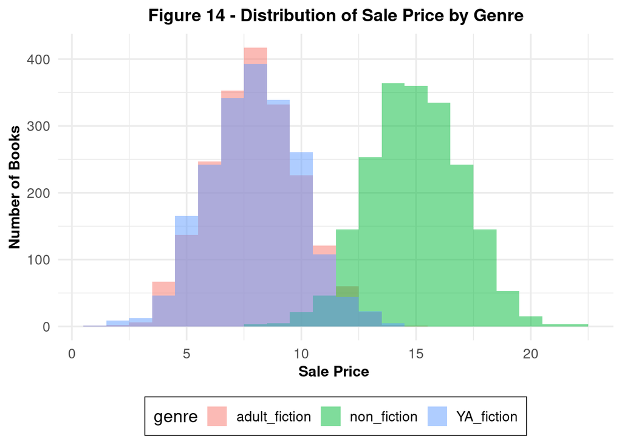

```r
ggplot(datasetBooksDuplicate, aes(x = sale.price, fill = genre)) +
  geom_histogram(position = "identity", alpha = 0.5, binwidth = 1) +
  scale_color_viridis_d() +
  labs( x = "Sale Price ",  y = "Number of Books", title = "Figure 14 - Distribution of Sale Price by Genre",) +   theme_minimal(base_size = 14) +
 theme(plot.title = element_text(size = 14, hjust = 0.5, face = "bold"),
        axis.title = element_text(size = 12, face = "bold"), legend.position = "bottom",
        legend.box.background = element_rect(color = "black", fill = "white"))
```

## Visualisations (Relationships)

Do books have more/fewer sales depending upon their average review scores and total number of reviews?

To show the relationship between the total number of reviews and the number of daily sales, we will first create a scatter plot.

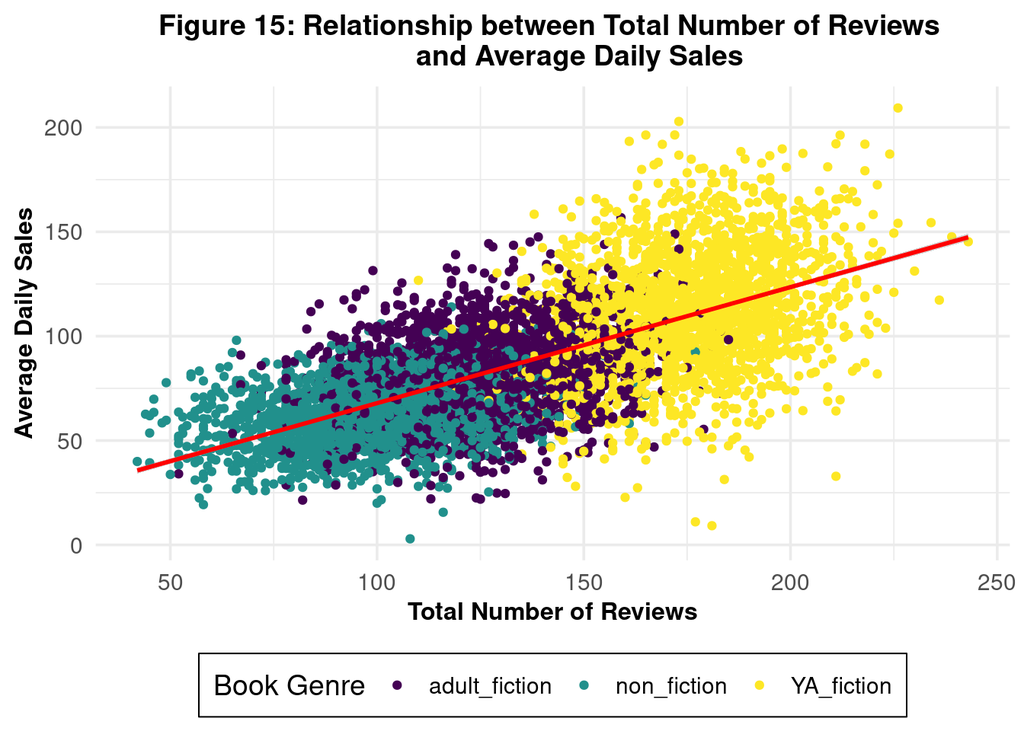

```r
ggplot(data = datasetBooksDuplicate, aes(x = total.reviews, y = daily.sales, color = genre)) +
  geom_point() +
  geom_smooth(method = "lm", color = "red") + # Add a linear regression line to show trend
  labs(title = "Figure 15: Relationship between Total Number of Reviews
       and Average Daily Sales", x = "Total Number of Reviews", y = "Average Daily Sales", color = "Book Genre") + scale_color_viridis_d() + theme_minimal(base_size = 14) + # Color scale for different genres
  theme(plot.title = element_text(size = 14, hjust = 0.5, face = "bold"),
        axis.title = element_text(size = 12, face = "bold"),
        legend.position = "bottom",  # Place legend at bottom to streamline visual flow
        legend.box.background = element_rect(color = "black", fill = "white"))
```

Figure 15’s best fit line demonstrates a positive correlation between the daily sales of books and their total number of reviews. This suggests that a book’s sales are influenced by its review count, with higher review numbers potentially leading to increased sales. To determine the statistical significance of this relationship, we will later examine the p-value.

Another scatter plot is created to illustrate the relationship between average reviews score and the number of daily sales.

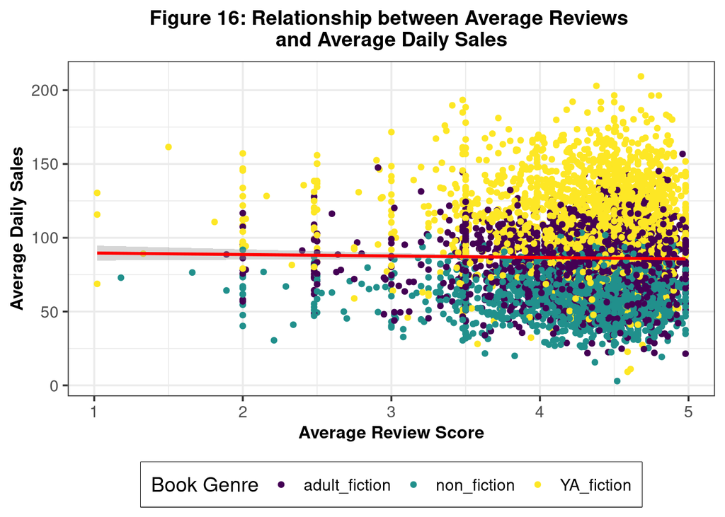

```r
ggplot(data = datasetBooksDuplicate, aes(x = avg.review, y = daily.sales, color = genre)) +
  geom_point() +  # Display scatter points with color based on 'genre'
  geom_smooth(method = "lm", color = "red") +  # Add a regression line in a subtle gray, dotted style
  labs(title = "Figure 16: Relationship between Average Reviews
and Average Daily Sales", x = "Average Review Score", y = "Average Daily Sales",color = "Book Genre") +
  scale_color_viridis_d() +
  theme_bw(base_size = 14) +  # Use a clean, white-background theme for contrast and readability
  theme(plot.title = element_text(size = 14, face = "bold", hjust = 0.5),
        axis.title = element_text(size = 12, face = "bold"),
        legend.position = "bottom",  # Place legend at bottom to streamline visual flow
        legend.box.background = element_rect(color = "black", fill = "white"),
        )
```

Figure 16’s line of best fit indicates a negligible correlation between daily sales and the average review score, suggesting that the latter has little to no impact on sales. From this analysis, it is clear that a book’s likelihood of being purchased is more strongly influenced by the quantity of its reviews rather than its average rating.

What is the effect of sale price upon the number of sales, and is this different across genres? Another scattor plot is created to show the relationship between sale price and daily sales.

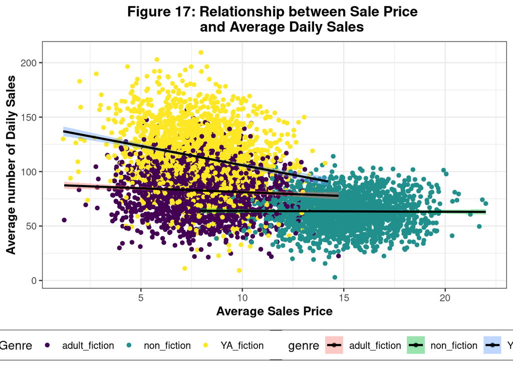

```r
ggplot(data = datasetBooksDuplicate, mapping = aes(x = sale.price, y = daily.sales, fill = genre)) +
    geom_point(mapping = aes(color = genre)) + scale_color_viridis_d() + #Points to represent each data point, color mapped by genre
  # Linear regression line to show trend
    geom_smooth(method="lm", col="#000000") + ggtitle("Figure 17: Relationship between Sale Price
    and Average Daily Sales") + theme_bw(base_size = 12) + theme(plot.title = element_text(size = 14, face = "bold", hjust = 0.5), axis.title = element_text(size = 12, face = "bold"),
        legend.position = "bottom",  # Legend at bottom for visual flow
        legend.box.background = element_rect(color = "black", fill = "white"), ) + labs(x= "Average Sales Price", y="Average number of Daily Sales", color = "Genre")
```

In Figure 17, when examining how sale prices vary across genres, it is observed that both young adult (YA) and adult fiction books show a negative correlation between their daily sales and sale prices. On the other hand, non-fiction ebooks present a trend line that is almost horizontal, suggesting that their sales hardly decrease even as sale prices rise. To gain deeper insights into these trends, conducting a regression analysis would prove valuable.

## Correlation

### Collinearity

Visualising the relationship between the total number of reviews and the average review score of books to assess for collinearity.

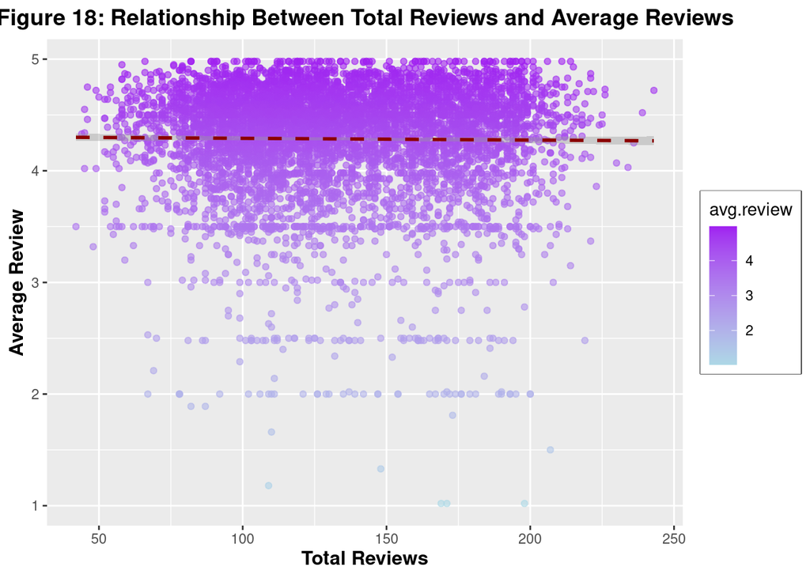

```r
ggplot(datasetBooksDuplicate, aes(x = total.reviews, y = avg.review)) +
  geom_point(aes(color = avg.review), alpha = 0.6) +
  scale_color_gradient(low = "lightblue", high = "purple") +
  geom_smooth(method = "lm", color = "darkred", linetype = "dashed") +
  labs(x = "Total Reviews", y = "Average Review",
       title = "Figure 18: Relationship Between Total Reviews and Average Reviews") +
theme(plot.title = element_text(size = 14, face = "bold", hjust = 0.5), axis.title = element_text(size = 12, face = "bold"),legend.position = "right",  # Legend at bottom for visual flow
        legend.box.background = element_rect(color = "black", fill = "white"))
```

Checking the correlation between variables by creating a correlation matrix.

```r
 # Using 'rcorr` from the Hmisc package to compute the correlation matrix between daily sales, avg review, total reviews and sale price
visualisedCorrMatrix2 <-rcorr(as.matrix(select_if(datasetBooksDuplicate,is.numeric)))
visualisedCorrMatrix2
```

```
##               avg.review daily.sales total.reviews sale.price
## avg.review          1.00       -0.02         -0.01       0.00
## daily.sales        -0.02        1.00          0.68      -0.51
## total.reviews      -0.01        0.68          1.00      -0.55
## sale.price          0.00       -0.51         -0.55       1.00
##
## n= 5976
##
##
## P
##               avg.review daily.sales total.reviews sale.price
## avg.review               0.1971      0.3795        0.7288
## daily.sales   0.1971                 0.0000        0.0000
## total.reviews 0.3795     0.0000                    0.0000
## sale.price    0.7288     0.0000      0.0000
```

```r
#  Return both the correlation coefficients and significance levels.
```

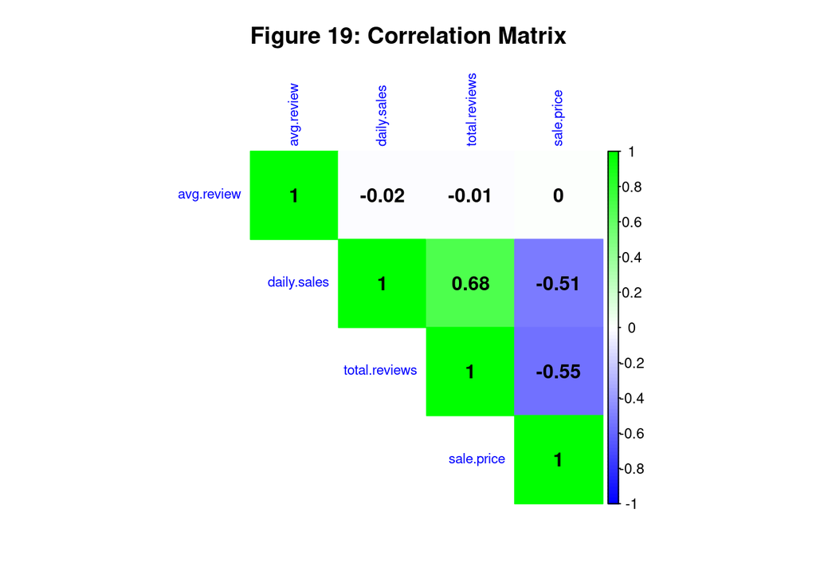

```r
#
corrplot(visualisedCorrMatrix2$r, method = "color",
         type = "upper", # Only showing the upper half of the matrix to avoid displaying unnecessary information
         tl.col = "blue",
         tl.srt = 90,
         col = colorRampPalette(c("blue", "white", "green"))(100),
         title = "Figure 19: Correlation Matrix",
         mar = c(3, 3, 3, 3),
         addCoef.col = "black",
         tl.cex = 0.7,
         cl.cex = 0.75
)
```

As the sale price of books increases, a decrease in daily book sales is seen, indicating a negative correlation between sale price and daily sales, with a collinearity value of 0.51 and a significance level of $p < 0.05. This statistically significant correlation suggests that the observed relationship between ebook sale prices and daily sales is unlikely to be a result of random chance.

Conversely, a positive correlation is found between the daily sales of books and the total number of reviews, shown by a correlation coefficient of 0.68 and a significance level of $p < 0.05. This confirms the statistical significance of the relationship, indicating that an increase in the number of reviews is associated with an increase in daily sales.

The analysis further reveals that the predictive variables largely exhibit independence, with minimal pairwise correlations. Specifically, the correlation between average review scores and total number of reviews is nearly nonexistent, with a negative collinearity value of 0.01, though its statistical significance, given a p value greater than 0.05, remains unconfirmed. The Variance Inflation Factor (VIF) scores will be used to further examine collinearity within our models.

The relationship between average review scores and daily book sales is negatively correlated, albeit weakly, with a collinearity value of 0.02. This suggests a virtually non-existent correlation, yet the lack of statistical significance, indicated by a $ value greater than 0.05, leaves this claim again unconfirmed.

## Modelling

### Total Review and Average Rating on Daily Sales

#### Simple Regression

We anticipate that as the number of reviews for that book increases, so will the overall daily sales. We will check if it is significant by using a simple linear regression model to estimate the effect of total number of reviews on average daily sales.

```r
simpleRegSalesTotalReviews <- lm(daily.sales ~ total.reviews, data = datasetBooksDuplicate)
summary(simpleRegSalesTotalReviews)
```

```
##
## Call:
## lm(formula = daily.sales ~ total.reviews, data = datasetBooksDuplicate)
##
## Residuals:
##      Min       1Q   Median       3Q      Max
## -103.755  -14.405   -0.754   13.543   94.382
##
## Coefficients:
##               Estimate Std. Error t value Pr(>|t|)
## (Intercept)   12.31348    1.07123   11.49   <2e-16 ***
## total.reviews  0.55598    0.00775   71.74   <2e-16 ***
## ---
## Signif. codes:  0 '***' 0.001 '**' 0.01 '*' 0.05 '.' 0.1 ' ' 1
##
## Residual standard error: 22.14 on 5974 degrees of freedom
## Multiple R-squared:  0.4628, Adjusted R-squared:  0.4627
## F-statistic:  5147 on 1 and 5974 DF,  p-value: < 2.2e-16
```

```r
confint(simpleRegSalesTotalReviews)
```

```
##                    2.5 %     97.5 %
## (Intercept)   10.2134771 14.4134916
## total.reviews  0.5407849  0.5711701
```

The results from this linear regression model reveal a positive and statistically significant correlation between total reviews and daily sales, shown by a high t-statistic of 71.74 and a p-value < 0.05. This indicates that with every additional review, daily sales are expected to increase by an average of 0.56 units, with the confidence interval for this estimate lying between 0.54 and 0.57.

Creating a simple linear regression model to determine the impact of average reviews on average daily sales

```r
simpleRegSalesAvgReviews <- lm(daily.sales~avg.review, data = datasetBooksDuplicate)
summary(simpleRegSalesAvgReviews)
```

```
##
## Call:
## lm(formula = daily.sales ~ avg.review, data = datasetBooksDuplicate)
##
## Residuals:
##     Min      1Q  Median      3Q     Max
## -83.222 -22.104  -4.697  18.286 123.368
##
## Coefficients:
##             Estimate Std. Error t value Pr(>|t|)
## (Intercept)  90.6494     3.3429   27.12   <2e-16 ***
## avg.review   -0.9994     0.7747   -1.29    0.197
## ---
## Signif. codes:  0 '***' 0.001 '**' 0.01 '*' 0.05 '.' 0.1 ' ' 1
##
## Residual standard error: 30.2 on 5974 degrees of freedom
## Multiple R-squared:  0.0002785,  Adjusted R-squared:  0.0001112
## F-statistic: 1.664 on 1 and 5974 DF,  p-value: 0.1971
```

```r
confint(simpleRegSalesAvgReviews)
```

```
##                 2.5 %     97.5 %
## (Intercept) 84.096121 97.2026404
## avg.review  -2.518069  0.5192204
```

The analysis indicates that the impact of average ratings on daily ebook sales is not statistically significant, with a t-statistic of 1.29 and a p-value of 0.197, exceeding the 0.05 threshold. 0.05. An increase in the average review score by one unit is linked to a average drop of 0.99 in daily sales, with the confidence interval for this effect ranging between -2.52 and 0.52.

These results suggest that average review scores may not serve as a reliable predictor for daily sales, as highlighted by the model’s insignificant p-value for the average review variable and a low R-squared value, indicating limited explanatory power.

#### Multiple regression

Combining both total and average reviews into a multiple linear regression model to determine the impact of both variables on the dependant variable daily sales.

```r
multipleRegAvgTotal <- lm(daily.sales ~ total.reviews + avg.review, data = datasetBooksDuplicate)
summary(multipleRegAvgTotal)
```

```
##
## Call:
## lm(formula = daily.sales ~ total.reviews + avg.review, data = datasetBooksDuplicate)
##
## Residuals:
##      Min       1Q   Median       3Q      Max
## -103.588  -14.436   -0.681   13.596   94.436
##
## Coefficients:
##               Estimate Std. Error t value Pr(>|t|)
## (Intercept)   14.62295    2.66993   5.477  4.5e-08 ***
## total.reviews  0.55589    0.00775  71.724  < 2e-16 ***
## avg.review    -0.53630    0.56791  -0.944    0.345
## ---
## Signif. codes:  0 '***' 0.001 '**' 0.01 '*' 0.05 '.' 0.1 ' ' 1
##
## Residual standard error: 22.14 on 5973 degrees of freedom
## Multiple R-squared:  0.4629, Adjusted R-squared:  0.4627
## F-statistic:  2574 on 2 and 5973 DF,  p-value: < 2.2e-16
```

```r
confint(multipleRegAvgTotal)
```

```
##                    2.5 %     97.5 %
## (Intercept)    9.3889305 19.8569635
## total.reviews  0.5407005  0.5710880
## avg.review    -1.6496109  0.5770125
```

The multiple regression analysis reveals a substantial positive correlation between the total number of reviews and daily sales, with a t-value of 71.72 and a p-value below 0.001. For every additional review, there’s an estimated increase of 0.56 in daily sales (95% CI = [0.54, 0.57]).

Conversely, the analysis shows that the influence of average review scores on daily sales is not statistically significant, evidenced by a t-value of -0.94 and a p-value of 0.345. An increase by one point in average reviews predicts a decrease of 0.54 in daily sales (95% CI = [-1.65, 0.58]).

#### Interaction Term

```r
multipleRegAvgTotalInteraction <- lm(daily.sales ~ avg.review * total.reviews, datasetBooksDuplicate)
summary(multipleRegAvgTotalInteraction)
```

```
##
## Call:
## lm(formula = daily.sales ~ avg.review * total.reviews, data = datasetBooksDuplicate)
##
## Residuals:
##      Min       1Q   Median       3Q      Max
## -103.544  -14.428   -0.669   13.593   94.448
##
## Coefficients:
##                           Estimate Std. Error t value Pr(>|t|)
## (Intercept)              12.703968   9.316581   1.364    0.173
## avg.review               -0.088728   2.157874  -0.041    0.967
## total.reviews             0.569883   0.065527   8.697   <2e-16 ***
## avg.review:total.reviews -0.003264   0.015181  -0.215    0.830
## ---
## Signif. codes:  0 '***' 0.001 '**' 0.01 '*' 0.05 '.' 0.1 ' ' 1
##
## Residual standard error: 22.14 on 5972 degrees of freedom
## Multiple R-squared:  0.4629, Adjusted R-squared:  0.4626
## F-statistic:  1716 on 3 and 5972 DF,  p-value: < 2.2e-16
```

```r
confint(multipleRegAvgTotalInteraction)
```

```
##                                2.5 %      97.5 %
## (Intercept)              -5.55989710 30.96783304
## avg.review               -4.31894089  4.14148481
## total.reviews             0.44142626  0.69834025
## avg.review:total.reviews -0.03302473  0.02649697
```

#### VIF

```r
# Examining the differences between the models' VIF scores with and without intraction terms.
vif(multipleRegAvgTotal)
```

```
## total.reviews    avg.review
##      1.000129      1.000129
```

```r
vif(multipleRegAvgTotalInteraction)
```

```
## there are higher-order terms (interactions) in this model
## consider setting type = 'predictor'; see ?vif
```

```
##               avg.review            total.reviews avg.review:total.reviews
##                 14.43702                 71.47826                 84.21525
```

In the multipleRegAvgTotal model, the VIF analysis presents values close to 1 for all variables, showing minimal risk of multicollinearity within the model.

The multipleRegAvgTotalInteraction model introduces an interaction variable (total.reviews * avg.review), leading to substantially increased VIF values. This rise in VIF is not a concern for multicollinearity, but due to including the interaction term into the regression analysis.

#### Anova

```r
# Comparing all models

anova(simpleRegSalesTotalReviews)
```

```
## Analysis of Variance Table
##
## Response: daily.sales
##                 Df  Sum Sq Mean Sq F value    Pr(>F)
## total.reviews    1 2522882 2522882  5146.6 < 2.2e-16 ***
## Residuals     5974 2928463     490
## ---
## Signif. codes:  0 '***' 0.001 '**' 0.01 '*' 0.05 '.' 0.1 ' ' 1
```

```r
anova(simpleRegSalesAvgReviews)
```

```
## Analysis of Variance Table
##
## Response: daily.sales
##              Df  Sum Sq Mean Sq F value Pr(>F)
## avg.review    1    1518 1518.37  1.6644 0.1971
## Residuals  5974 5449827  912.26
```

```r
anova(multipleRegAvgTotal)
```

```
## Analysis of Variance Table
##
## Response: daily.sales
##                 Df  Sum Sq Mean Sq   F value Pr(>F)
## total.reviews    1 2522882 2522882 5146.5291 <2e-16 ***
## avg.review       1     437     437    0.8918  0.345
## Residuals     5973 2928026     490
## ---
## Signif. codes:  0 '***' 0.001 '**' 0.01 '*' 0.05 '.' 0.1 ' ' 1
```

```r
anova(multipleRegAvgTotal,multipleRegAvgTotalInteraction)
```

```
## Analysis of Variance Table
##
## Model 1: daily.sales ~ total.reviews + avg.review
## Model 2: daily.sales ~ avg.review * total.reviews
##   Res.Df     RSS Df Sum of Sq      F Pr(>F)
## 1   5973 2928026
## 2   5972 2928004  1    22.662 0.0462 0.8298
```

```r
anova(simpleRegSalesTotalReviews,simpleRegSalesAvgReviews,multipleRegAvgTotal,multipleRegAvgTotalInteraction)
```

```
## Analysis of Variance Table
##
## Model 1: daily.sales ~ total.reviews
## Model 2: daily.sales ~ avg.review
## Model 3: daily.sales ~ total.reviews + avg.review
## Model 4: daily.sales ~ avg.review * total.reviews
##   Res.Df     RSS Df Sum of Sq         F Pr(>F)
## 1   5974 2928463
## 2   5974 5449827  0  -2521363
## 3   5973 2928026  1   2521800 5143.5020 <2e-16 ***
## 4   5972 2928004  1        23    0.0462 0.8298
## ---
## Signif. codes:  0 '***' 0.001 '**' 0.01 '*' 0.05 '.' 0.1 ' ' 1
```

The independent variable, total number of reviews, has a significant effect on the dependant variable, daily sales, with a F-value of 5146.6, and a significance level of p <0.05. The p-value being less than 0.05 confirms the statistical significance of this effect, majorly reducing the probability that the findings are accidental.

The other independent variable, average daily reviews, has no significant effect on daily sales, as shown by a F-value of 1.6644 and a p-value of 0.1971. This comparison, employing the same sample size, shows a considerably weaker link for average reviews relative to total reviews. The p-value > 0.05 means there is insufficient evidence to conclude that average reviews has a significant effect on daily sales.

This is because adding the interaction term (`total.reviews * avg.review`) in a new model does not provide an additional improvement on top of this. Despite the integration of this term, the basic multiple regression model without the interaction term proves more effective, as highlighted by a higher F-value of 5143.50 and p < 0.001 , compared to the interaction terms low F-value of 0.046 and p > 0.01.

### Daily Sales and Sale prices

#### Regression

```r
simpleRegDailySales <- lm(daily.sales~sale.price, data = datasetBooksDuplicate)
summary(simpleRegDailySales)
```

```
##
## Call:
## lm(formula = daily.sales ~ sale.price, data = datasetBooksDuplicate)
##
## Residuals:
##     Min      1Q  Median      3Q     Max
## -87.815 -17.407  -1.903  15.230 113.668
##
## Coefficients:
##              Estimate Std. Error t value Pr(>|t|)
## (Intercept) 127.34827    0.95790  132.94   <2e-16 ***
## sale.price   -3.97945    0.08709  -45.69   <2e-16 ***
## ---
## Signif. codes:  0 '***' 0.001 '**' 0.01 '*' 0.05 '.' 0.1 ' ' 1
##
## Residual standard error: 26 on 5974 degrees of freedom
## Multiple R-squared:  0.259,  Adjusted R-squared:  0.2589
## F-statistic:  2088 on 1 and 5974 DF,  p-value: < 2.2e-16
```

```r
confint(simpleRegDailySales)
```

```
##                  2.5 %     97.5 %
## (Intercept) 125.470442 129.226105
## sale.price   -4.150183  -3.808724
```

In the linear regression model, a t-value of 45.69 and a p-value less than 0.001 (95% CI [-4.15,-3.81]) show that there is a significant negative impact of sale price on daily sales, and every 1 point increase in sale price predicts an average reduction in daily sales of 3.98 points (CI = [-4.15, -3.80]). Now, let’s incorporate genre into the model and see if there is a significant effect on the daily sales.

```r
simpleRegDailySalesGenre <- lm(daily.sales ~ sale.price + genre, datasetBooksDuplicate)
summary(simpleRegDailySalesGenre)
```

```
##
## Call:
## lm(formula = daily.sales ~ sale.price + genre, data = datasetBooksDuplicate)
##
## Residuals:
##      Min       1Q   Median       3Q      Max
## -103.178  -13.746    0.301   13.551   96.266
##
## Coefficients:
##                  Estimate Std. Error t value Pr(>|t|)
## (Intercept)       93.9506     1.2442  75.511  < 2e-16 ***
## sale.price        -1.4289     0.1432  -9.976  < 2e-16 ***
## genrenon_fiction  -9.0697     1.2228  -7.417 1.36e-13 ***
## genreYA_fiction   30.4979     0.6994  43.608  < 2e-16 ***
## ---
## Signif. codes:  0 '***' 0.001 '**' 0.01 '*' 0.05 '.' 0.1 ' ' 1
##
## Residual standard error: 22.07 on 5972 degrees of freedom
## Multiple R-squared:  0.4665, Adjusted R-squared:  0.4662
## F-statistic:  1740 on 3 and 5972 DF,  p-value: < 2.2e-16
```

```r
confint(simpleRegDailySalesGenre)
```

```
##                       2.5 %    97.5 %
## (Intercept)       91.511461 96.389642
## sale.price        -1.709687 -1.148100
## genrenon_fiction -11.466846 -6.672626
## genreYA_fiction   29.126894 31.868927
```

This model reinforces the inverse relationship between sale price and average daily sale, showing a decrease of 1.43 units in daily sales for every one unit increase in sale price, with a t value of -9.98 and a p value of <.001 (95% CI [-1.71, -1.15]), even after controlling for other variables. This suggests a significant deviation from zero.

#### Interaction

```r
simpleRegDailySalesGenreInteraction <- lm(daily.sales~sale.price*genre, data = datasetBooksDuplicate)
summary(simpleRegDailySalesGenreInteraction)
```

```
##
## Call:
## lm(formula = daily.sales ~ sale.price * genre, data = datasetBooksDuplicate)
##
## Residuals:
##      Min       1Q   Median       3Q      Max
## -104.828  -13.694    0.197   13.530   96.297
##
## Coefficients:
##                             Estimate Std. Error t value Pr(>|t|)
## (Intercept)                  88.2197     2.0481  43.074  < 2e-16 ***
## sale.price                   -0.7100     0.2495  -2.846  0.00444 **
## genrenon_fiction            -23.6873     4.1929  -5.649 1.68e-08 ***
## genreYA_fiction              52.9344     2.8734  18.423  < 2e-16 ***
## sale.price:genrenon_fiction   0.6399     0.3476   1.841  0.06574 .
## sale.price:genreYA_fiction   -2.8216     0.3504  -8.053 9.69e-16 ***
## ---
## Signif. codes:  0 '***' 0.001 '**' 0.01 '*' 0.05 '.' 0.1 ' ' 1
##
## Residual standard error: 21.87 on 5970 degrees of freedom
## Multiple R-squared:  0.4764, Adjusted R-squared:  0.4759
## F-statistic:  1086 on 5 and 5970 DF,  p-value: < 2.2e-16
```

```r
simpleRegDailySales_emm <- emmeans(simpleRegDailySalesGenre, ~genre)
simpleRegDailySales_emm
```

```
##  genre         emmean    SE   df lower.CL upper.CL
##  adult_fiction   79.2 0.596 5972     78.1     80.4
##  non_fiction     70.2 0.833 5972     68.5     71.8
##  YA_fiction     109.7 0.599 5972    108.6    110.9
##
## Confidence level used: 0.95
```

```r
# Calculating 95% confidence intervals for pairwise comparisons of genre along with significance levels.

simpleRegDailySales_pair <- confint(pairs(simpleRegDailySales_emm))
simpleRegDailySales_pair
```

```
##  contrast                    estimate    SE   df lower.CL upper.CL
##  adult_fiction - non_fiction     9.07 1.223 5972      6.2     11.9
##  adult_fiction - YA_fiction    -30.50 0.699 5972    -32.1    -28.9
##  non_fiction - YA_fiction      -39.57 1.226 5972    -42.4    -36.7
##
## Confidence level used: 0.95
## Conf-level adjustment: tukey method for comparing a family of 3 estimates
```

When the model is adjusted to include an interaction term, sale price interacting with non-fiction books does not emerge as a significant factor, showing a t-value of 1.84, with a p value > 0,01. In contrast, the interaction between sale price and Young Adult (YA) fiction is identified as a significant predictor, with a t-value of -8.05 (p < .001).

Young Adult (YA) fiction leads with an average daily sale of 109.7 and a 95% confidence interval of 108.5 to 110.9, indicating it has the highest sales among the genres, followed by adult fiction. Adult fiction records an average of 79.2, within a 95% confidence interval ranging from 78.1 to 80.4. Non-fiction books have lower average daily sales at 70.2, with the 95% confidence interval spanning from 68.6 to 71.8. Non-fiction shows the least growth in daily sales.

This analysis underscores that while higher sale prices generally correlate with reduced daily sales, the effect of increasing prices varies across genres, influencing their daily sales differently. Therefore the effect of changing sale price upon the number of sales varies across different genres.

#### VIF

```r
vif(simpleRegDailySalesGenre)
```

```
##                GVIF Df GVIF^(1/(2*Df))
## sale.price 3.755568  1        1.937929
## genre      3.755568  2        1.392095
```

```r
vif(simpleRegDailySalesGenreInteraction)
```

```
## there are higher-order terms (interactions) in this model
## consider setting type = 'predictor'; see ?vif
```

```
##                        GVIF Df GVIF^(1/(2*Df))
## sale.price         11.60395  1        3.406458
## genre             737.91545  2        5.211967
## sale.price:genre 1046.63868  2        5.687864
```

In the simpleRegDailySalesGenre model, the VIF analysis presents values below 5, showing minimal risk of multicollinearity among genre, average daily sales and sale price.

The simpleRegDailySalesGenreInteraction model introduces an interaction variable (sale.price * genre), leading to substantially increased VIF values. This rise in VIF is not a concern for multicollinearity, but due to including the interaction term into the regression analysis.

#### Annova

```r
# Comparing the interaction model with the base model.
anova(simpleRegDailySales)
```

```
## Analysis of Variance Table
##
## Response: daily.sales
##              Df  Sum Sq Mean Sq F value    Pr(>F)
## sale.price    1 1411792 1411792  2087.9 < 2.2e-16 ***
## Residuals  5974 4039553     676
## ---
## Signif. codes:  0 '***' 0.001 '**' 0.01 '*' 0.05 '.' 0.1 ' ' 1
```

```r
anova(simpleRegDailySalesGenre)
```

```
## Analysis of Variance Table
##
## Response: daily.sales
##              Df  Sum Sq Mean Sq F value    Pr(>F)
## sale.price    1 1411792 1411792  2898.8 < 2.2e-16 ***
## genre         2 1131046  565523  1161.2 < 2.2e-16 ***
## Residuals  5972 2908507     487
## ---
## Signif. codes:  0 '***' 0.001 '**' 0.01 '*' 0.05 '.' 0.1 ' ' 1
```

```r
anova(simpleRegDailySalesGenreInteraction)
```

```
## Analysis of Variance Table
##
## Response: daily.sales
##                    Df  Sum Sq Mean Sq  F value    Pr(>F)
## sale.price          1 1411792 1411792 2952.615 < 2.2e-16 ***
## genre               2 1131046  565523 1182.731 < 2.2e-16 ***
## sale.price:genre    2   53952   26976   56.418 < 2.2e-16 ***
## Residuals        5970 2854555     478
## ---
## Signif. codes:  0 '***' 0.001 '**' 0.01 '*' 0.05 '.' 0.1 ' ' 1
```

```r
anova(simpleRegDailySalesGenre,simpleRegDailySales,simpleRegDailySalesGenreInteraction)
```

```
## Analysis of Variance Table
##
## Model 1: daily.sales ~ sale.price + genre
## Model 2: daily.sales ~ sale.price
## Model 3: daily.sales ~ sale.price * genre
##   Res.Df     RSS Df Sum of Sq       F    Pr(>F)
## 1   5972 2908507
## 2   5974 4039553 -2  -1131046 1182.73 < 2.2e-16 ***
## 3   5970 2854555  4   1184998  619.57 < 2.2e-16 ***
## ---
## Signif. codes:  0 '***' 0.001 '**' 0.01 '*' 0.05 '.' 0.1 ' ' 1
```

The sale price has a significant effect on the daily sales, with the model simpleRegDailySales having a F-score of 2088, p <0.05. The genre has a significant effect on the daily sales, with the model simpleRegDailySalesGenre having a F-score of 1161, p <0.001.

Incorporating genre alongside sale price into the model results in a significant reduction in the Residual Sum of Squares (RSS), amounting to 1,131,046. This change produces a highly significant F-statistic of 1161.2, with a p-value < 0.001 underscoring the key role of genre in influencing daily sales.

By further integrating both sale price and genre, including their interaction term into the model, RSS experiences an additional decrease of 53,952. The model’s F-statistic, standing at 56.418 and paired with a p-value less than 2.2e-16, implies that adding the interaction term between sale price and genre significantly enhances the model’s ability to predict daily sales. This combination, incorporating the interaction term, is identified as the most effective predictor of daily sales among the three models just tested above.

.